# Snake tracking

Author

Marc Vez-Garzón

# 1 Introduction

This document includes all the parts dedicated to analyse the movement and behaviour of multiple individuals of *Hemorrhois hippocrepis* collected on the island of Ibiza during the months of April to June 2023 and 2024.

In this study, we try to find if there are significant differences in the use of space, boldness, and exploratory behaviour between regions of the island recently invaded with populations of *Podarcis pityusensis* (endemic lizard of the island of Ibiza, threatened by this invasive snake) and regions of the island invaded for a long time and without natural populations of lizards.

# 2 Packages

```r
library(viridis)
library(readxl)
library(writexl)
library(ggplot2)
library(tidyr)
library(plyr)
library(sp)
library(lubridate)
library(dplyr)
library(irr)
library(utils)
library(tibble)
library(EnvStats)
library(survival)
library(ggsurvfit)
library(gtsummary)
library(Hmisc)
library(ggpubr)
library(vegan)
library(sm)
library(survminer)
library(ggfortify)
library(factoextra)
library(graphics)
library(olsrr)
library(corrplot)
library(car)
library(censReg)
library(patchwork)
```

# 3 Load data

Load the required files needed to run this script. Files can be found in https://github.com/marcvez/Snake_tracking.git

```r
# Set working directory
setwd("C:/Users/marc9/Desktop/Marc/CREAF/Snake tracking")

# Load file with snake info
Snake_data <- read_excel("Snake_captures.xlsx")

# Subset tracked snakes
Snake_data_tracked <- Snake_data[Snake_data$Tracking %in% c("Y"), ]

# Subset tracked + genetics/isotopes + x-ray sample
Snake_data_tracked <- Snake_data_tracked[!is.na(Snake_data_tracked$SVL), ]

# Load snake 3D array
load("Snake_array.Rda")

# Load arena 3D array
load("Arena_array.Rda")

# Load summary file from all snake trials
summary_tracking <- read_excel("summary_tracking.xlsx")

# Load summary file from all snake trials + environmental variables
summary_tracking_complete <- read_excel("summary_tracking_complete.xlsx")
```

For some analyses, we might need a data frame with only the first trials of each snakes, without gravid females, or with only those individuals that got out of the initial refuge and explored the arena.

```r
time_limit <- 3000
# No repeated indiviuals, only with new ones
summary_tracking_complete_no_rep <- summary_tracking_complete[summary_tracking_complete$Repeatability == "N",]

# Also, for some individuals, we are only going to use individuals that actually got out of the refuge (Body-out != 3000)
summary_tracking_complete_no_rep_outside <- summary_tracking_complete_no_rep[summary_tracking_complete_no_rep$Time_body_out_sec_raw != time_limit, ]

# Create one without gravid individuals that got out (visual exploration)
summary_tracking_complete_no_rep_outside_noeggs <- summary_tracking_complete_no_rep_outside[summary_tracking_complete_no_rep_outside$N_eggs == 0, ]

# Create one without gravid individuals with censored data (head-out and body-out)
summary_tracking_complete_no_rep_noeggs <- summary_tracking_complete_no_rep[summary_tracking_complete_no_rep$N_eggs == 0, ]
```

## 3.1 Snake position extraction

Don’t run if `Snake_array` and `Arena_array` have been already loaded, as these functions take a lot of time to run.

`Snake_array`

```r
# Variable names for each column
variable_names <- c("t", "x", "y", "Central_area", "Intermediate_area", "Refuge_area_1", "Refuge_area_2", "Initial_refuge", "Distant_wall", "Lateral_1", "Lateral_2", "Arena_area", "Area", "dist_hole_0", "dist_hole_1", "dist_hole_2", "dist_hole_3", "dist_hole_4", "dist_min", "hole_dist_min", "dist_traveled", "behaviour")

# We create empty data frame that is going to store: x axis = time step, y = variables, z = individuals
Snake_array <-  array(NA, dim = c(3600, length(variable_names), nrow(Snake_data_tracked)))

# We set the column names for the variables across the array
dimnames(Snake_array)[[2]] <- variable_names

# We set the ID code for all tracked snakes across the array
dimnames(Snake_array)[[3]] <- Snake_data_tracked$Snake_ID


# For each tracked individual
# THIS TAKES A LOT OF TIME. DO NOT RUN AND LOAD DIRECTLY FROM WD
for(i in 1:nrow(Snake_data_tracked)){

  # If it is the first trial (no repeatability)...
  if(Snake_data_tracked$Repeatability[i] == "N"){

    # ... set the working directory in the correct folder...
    setwd("C:/Users/marc9/Desktop/Marc/CREAF/Snake tracking/Excels tracking")

    # ... and if it didn't get out of the original refuge, fill the correspondent data layer with 0. Otherwise...
    if(Snake_data_tracked$Time_head_out_sec_raw[i] == "NA"){

      # We copy an already complete file
      coordinates_complete <- as.data.frame(Snake_array[, , 1])

      # And fill with 0
      coordinates_complete$x <- 0
      coordinates_complete$y <- 0
      coordinates_complete$Central_area <- 0
      coordinates_complete$Intermediate_area <- 0
      coordinates_complete$Refuge_area_1 <- 0
      coordinates_complete$Refuge_area_2 <- 0
      coordinates_complete$Initial_refuge <- 0
      coordinates_complete$Distant_wall <- 0
      coordinates_complete$Lateral_1 <- 0
      coordinates_complete$Lateral_2 <- 0
      coordinates_complete$Arena_area <- 0
      coordinates_complete$Area <- "Initial refuge"
      coordinates_complete$dist_hole_0 <- 0
      coordinates_complete$dist_hole_1 <- 0.86
      coordinates_complete$dist_hole_2 <- 1.3
      coordinates_complete$dist_hole_3 <- 1.3
      coordinates_complete$dist_hole_4 <- 0.86
      coordinates_complete$dist_min <- 0
      coordinates_complete$hole_dist_min <- "dist_hole_0"
      coordinates_complete$dist_traveled <- 0
      coordinates_complete$behaviour <- "hidden"

      # It might happen that the snake is being recorded for more than 1h, and we want to know their behaviour in 1h-tests. It's for this reason that we are going to cut all videos to 1h (3600 sec). If the video lasts less than 1h, for the moment we are not going to do anything.
      if(nrow(coordinates_complete) > 3600){

        coordinates_complete <- coordinates_complete[1:3600, ]

      } else {

      }

      Snake_array[1:nrow(coordinates_complete), , i] <- as.matrix(coordinates_complete[ , ])

      assign("Snake_array", Snake_array, envir=globalenv())

      paste("Snake_array", i)


      # ... extract data from its tracked Excel file.
    } else if(Snake_data_tracked$Time_head_out_sec_raw[i] != "NA"){

      # Select data based on snake's ID
      data_name <- paste0(Snake_data_tracked$Snake_ID[i], "_coordinates.xlsx")

      # Standardized name for data
      coordinates <- read_excel(data_name)

      # Select arena limits and refuges from specific individual
      name_arena <- paste0(Snake_data_tracked$Snake_ID[i], "_arena.xlsx")

      arena <- read_excel(name_arena)

      # How much time does the snake hide before first head-out
      sec_bf_head_out <- as.numeric(Snake_data_tracked$Time_head_out_sec_raw[i])

      # Let's find which seconds is the snake missing in the recording (hidden)
      missing_time <- min(coordinates$t):max(coordinates$t)

      # How many seconds does the snake stay inside the refuges after coming out the initial refuge
      missing_time_recorded <- length(missing_time[!missing_time %in% coordinates$t])

      # Which seconds is the snake missing
      missing_time_sec <- missing_time[!missing_time %in% coordinates$t]


      # See in which area is the snake at each time step

      # The snake, even if it is outside the arena, is still over a certain area, so we are going to widen the limits of the areas for detecting in which area is the snake even if it is outside the arena limits. It does not have an effect over the behaviour

      off_limit <- 0.2

      # Central area
      Central_area <- point.in.polygon(coordinates$x,
                                       coordinates$y,
                                       c(arena[1, 2]- 0.75, arena[2, 2] - 0.75, arena[3, 2] + 0.75, arena[4, 2] + 0.75),
                                       c(arena[1, 3] + 0.5, arena[2, 3] - 0.5, arena[3, 3] - 0.5, arena[4, 3] + 0.5))

      coordinates$Central_area <- Central_area

      # Intermediate area
      Intermediate_area <- point.in.polygon(coordinates$x,
                                            coordinates$y,
                                            c(arena[1, 2]- 0.5, arena[2, 2] - 0.5, arena[3, 2] + 0.5, arena[4, 2] + 0.5),
                                            c(arena[1, 3] + 0.25, arena[2, 3] - 0.25, arena[3, 3] - 0.25, arena[4, 3] + 0.25))

      coordinates$Intermediate_area <- Intermediate_area

      coordinates$Intermediate_area <- coordinates$Intermediate_area - coordinates$Central_area

      # Refuge area 1
      Refuge_area_1 <- point.in.polygon(coordinates$x,
                                        coordinates$y,
                                        c(arena[1, 2]- 0.25, arena[2, 2] - 0.25, arena[2, 2] - 0.5, arena[2, 2] - 0.5),
                                        c(arena[1, 3] + 0.25, arena[2, 3] - 0.25, arena[2, 3] - 0.25, arena[1, 3] + 0.25))

      coordinates$Refuge_area_1 <- Refuge_area_1

      # Refuge area 2
      Refuge_area_2 <- point.in.polygon(coordinates$x,
                                        coordinates$y,
                                        c(arena[4, 2] + 0.5, arena[3, 2] + 0.5, arena[3, 2] + 0.25, arena[4, 2] + 0.25),
                                        c(arena[4, 3] + 0.25, arena[3, 3] - 0.25, arena[3, 3] - 0.25, arena[4, 3] + 0.25))
```

```r
      coordinates$Refuge_area_2 <- Refuge_area_2


      # Initial refuge area
      Initial_refuge <- point.in.polygon(coordinates$x,
                                         coordinates$y,
                                         c(arena[1, 2] - 0.25, arena[1, 2] -0.25, arena[4, 2] + 0.25, arena[4, 2] + 0.25),
                                         c(arena[1, 3] - off_limit, arena[1, 3] + 0.25, arena[4, 3] + 0.25, arena[4, 3] - off_limit))

      coordinates$Initial_refuge <- Initial_refuge


      # Distant wall area
      Distant_wall <- point.in.polygon(coordinates$x,
                                       coordinates$y,
                                       c(arena[2, 2] - 0.25, arena[2, 2] - 0.25, arena[3, 2] + 0.25, arena[3, 2] + 0.25),
                                       c(arena[2, 3] - 0.25, arena[2, 3] + off_limit, arena[3, 3] + off_limit, arena[3, 3] - 0.25))

      coordinates$Distant_wall <- Distant_wall


      # Lateral refuge area 1
      Lateral_1 <- point.in.polygon(coordinates$x,
                                    coordinates$y,
                                    c(arena[1, 2] + off_limit, arena[2, 2] + off_limit, arena[2, 2] - 0.25, arena[1, 2] - 0.25),
                                    c(arena[1, 3] - off_limit, arena[2, 3] + off_limit, arena[2, 3] + off_limit, arena[1, 3] - off_limit))

      coordinates$Lateral_1 <- Lateral_1

      # Lateral refuge area 2
      Lateral_2 <- point.in.polygon(coordinates$x,
                                    coordinates$y,
                                    c(arena[3, 2] - off_limit, arena[4, 2] - off_limit, arena[4, 2] + 0.25, arena[3, 2] + 0.25),
                                    c(arena[3, 3] + off_limit, arena[4, 3] - off_limit, arena[4, 3] - off_limit, arena[3, 3] + off_limit))

      coordinates$Lateral_2 <- Lateral_2


      # Arena area. We are going to expand the arena limits 2cm on each side, in order to take into account edge exploration as inside the arena, not ouside
      Arena_area <- point.in.polygon(coordinates$x,
                                     coordinates$y,
                                     c(arena[1, 2] + 0.02, arena[2, 2] + 0.02, arena[3, 2] - 0.02, arena[4, 2] - 0.02),
                                     c(arena[1, 3] - 0.02, arena[2, 3] + 0.02, arena[3, 3] + 0.02, arena[4, 3] - 0.02))

      coordinates$Arena_area <- Arena_area

      # Column that indicates the area the snake is at every time step
      for(j in 1:nrow(coordinates)){

        if(coordinates$Arena_area[j] == 1 | coordinates$Arena_area[j] == 0){

          if(coordinates$Lateral_2[j] == 1){

            coordinates$Area[j] <- "Lateral 2"

          } else if(coordinates$Lateral_1[j] == 1){

            coordinates$Area[j] <- "Lateral 1"

          } else if(coordinates$Distant_wall[j] == 1){

            coordinates$Area[j] <- "Distant wall"

          } else if(coordinates$Refuge_area_1[j] == 1){

            coordinates$Area[j] <- "Refuge area 1"

          } else if(coordinates$Refuge_area_2[j] == 1) {

            coordinates$Area[j] <- "Refuge area 2"

          } else if(coordinates$Initial_refuge[j] == 1) {

            coordinates$Area[j] <- "Initial refuge"

          } else if(coordinates$Intermediate_area[j] == 1) {

            coordinates$Area[j] <- "Intermediate area"

          } else if(coordinates$Central_area[j] == 1){

            coordinates$Area[j] <- "Central area"

          } else  {

            if (j == 1){

              # Initial frame
              coordinates$Area[j] <- "Initial refuge"

            } else {

              # If any of the conditions are met, repeat previous area
              coordinates$Area[j] <- coordinates$Area[j - 1]

            }

          }

        }

      }



      # Distance to each hole

      # Entrance hole (hole_0)
      hole_0 <- c(arena[5, 2], arena[5, 3])

      for(k in 1:nrow(coordinates)){

        coordinates$dist_hole_0[k] <- sqrt((coordinates$x[k] - as.numeric(hole_0[1]))^2 + (coordinates$y[k] - as.numeric(hole_0[2]))^2)

      }

      # Hole 1
      hole_1 <- c(arena[6, 2], arena[6, 3])

      for(k in 1:nrow(coordinates)){

        coordinates$dist_hole_1[k] <- sqrt((coordinates$x[k] - as.numeric(hole_1[1]))^2 + (coordinates$y[k] - as.numeric(hole_1[2]))^2)

      }

      # Hole 2
      hole_2 <- c(arena[7, 2], arena[7, 3])

      for(k in 1:nrow(coordinates)){

        coordinates$dist_hole_2[k] <- sqrt((coordinates$x[k] - as.numeric(hole_2[1]))^2 + (coordinates$y[k] - as.numeric(hole_2[2]))^2)

      }

      # Hole 3
      hole_3 <- c(arena[8, 2], arena[8, 3])

      for(k in 1:nrow(coordinates)){

        coordinates$dist_hole_3[k] <- sqrt((coordinates$x[k] - as.numeric(hole_3[1]))^2 + (coordinates$y[k] - as.numeric(hole_3[2]))^2)

      }

      # Hole 4
      hole_4 <- c(arena[9, 2], arena[9, 3])

      for(k in 1:nrow(coordinates)){

        coordinates$dist_hole_4[k] <- sqrt((coordinates$x[k] - as.numeric(hole_4[1]))^2 + (coordinates$y[k] - as.numeric(hole_4[2]))^2)

      }


      # Which is the hole the snake is closest to at each moment
      for(k in 1:nrow(coordinates)){

        a <- coordinates$dist_hole_0[k]
        b <- coordinates$dist_hole_1[k]
        c <- coordinates$dist_hole_2[k]
        d <- coordinates$dist_hole_3[k]
        e <- coordinates$dist_hole_4[k]

        # Write the distance to the closest hole
        coordinates$dist_min[k] <- min(c(a, b, c, d, e))

        # And the name of that hole
        coordinates$hole_dist_min[k] <- colnames(coordinates[which((coordinates[k, ] == coordinates$dist_min[k]) == TRUE)])[1]

      }


      # Which distance has the snake traveled from 1 sec to the next one
      dist_traveled <- data.frame(matrix(ncol = 1, nrow = nrow(coordinates)))

      for(k in 2:nrow(coordinates)){

        dist_traveled[k, 1] <- sqrt((coordinates$x[k] - coordinates$x[k - 1])^2 + (coordinates$y[k] - coordinates$y[k - 1])^2)

      }

      dist_traveled[1, 1] <- 0

      coordinates$dist_traveled <- as.numeric(dist_traveled[, 1])
```

```r
      # Which behaviour is the snake exhibiting?
      for(k in 1:nrow(coordinates)){

        if(coordinates$Arena_area[k] == 0){

          if(coordinates$dist_traveled[k] < 0.01){

            coordinates$behaviour[k] <- "hiding / head-out"

          } else {

            coordinates$behaviour[k] <- "exploring wall"

          }

        } else {

          if(coordinates$dist_traveled[k] < 0.01 && coordinates$dist_min[k] < 0.1){

            coordinates$behaviour[k] <- "head-out"

          } else if(coordinates$dist_traveled[k] < 0.01 && coordinates$dist_min[k] > 0.1){

            coordinates$behaviour[k] <- "immobile exposed"

          } else {

            coordinates$behaviour[k] <- "moving"

          }

        }

      }


      # We put the correct time steps to each frame
      coordinates$t <- coordinates$t + as.numeric(sec_bf_head_out) + 1

      # We create a data set that is going to keep all the information to what happens during the whole video

      # How long is the total video (nº sec recorded + nº sec snake is hidden bf exiting for the first time + nº seconds hidden during recording)
      total_frames <- as.numeric(sec_bf_head_out) + nrow(coordinates) + missing_time_recorded

      # Column names
      col_names_coordinates <- colnames(coordinates)

      # We create the data frame
      coordinates_complete <- data.frame(matrix(ncol = ncol(coordinates), nrow = total_frames))

      # And put the column names
      colnames(coordinates_complete) <- col_names_coordinates

      # Seconds that the whole recordind lasts
      coordinates_complete$t <- seq(1:total_frames)

      # Now, we assign each recorded parameter to its correspondent second on the 1h record
      for(k in 1:nrow(coordinates)){

        values_coordinates <- coordinates[k, ]

        coordinates_complete[as.numeric(values_coordinates[1]), ] <- values_coordinates


      }


      # Values for when the snake is still inside the initial refuge
      for(j in 1:nrow(coordinates_complete)){

        # If the snake hasn't exited the initial refuge
        if(j <= as.numeric(sec_bf_head_out)){

          coordinates_complete$x[j] <- 0
          coordinates_complete$y[j] <- 0
          coordinates_complete$Central_area[j] <- 0
          coordinates_complete$Intermediate_area[j] <- 0
          coordinates_complete$Refuge_area_1[j] <- 0
          coordinates_complete$Refuge_area_2[j] <- 0
          coordinates_complete$Initial_refuge[j] <- 0
          coordinates_complete$Distant_wall[j] <- 0
          coordinates_complete$Lateral_1[j] <- 0
          coordinates_complete$Lateral_2[j] <- 0
          coordinates_complete$Arena_area[j] <- 0
          coordinates_complete$Area[j] <- "Initial refuge"
          coordinates_complete$dist_hole_0[j] <- 0
          coordinates_complete$dist_hole_1[j] <- coordinates_complete$dist_hole_1[as.numeric(sec_bf_head_out) + 1]
          coordinates_complete$dist_hole_2[j] <- coordinates_complete$dist_hole_2[as.numeric(sec_bf_head_out) + 1]
          coordinates_complete$dist_hole_3[j] <- coordinates_complete$dist_hole_3[as.numeric(sec_bf_head_out) + 1]
          coordinates_complete$dist_hole_4[j] <- coordinates_complete$dist_hole_4[as.numeric(sec_bf_head_out) + 1]
          coordinates_complete$dist_min[j] <- 0
          coordinates_complete$hole_dist_min[j] <- "dist_hole_0"
          coordinates_complete$dist_traveled[j] <- 0
          coordinates_complete$behaviour[j] <- "hidden"


        } else {

          # If the snake is missing (hidden), which parameters are going to exhibit those frames. We are going to copy the parameters from the last recorded frame, except specific parameters.
          if(is.na(coordinates_complete$x[j]) == TRUE) {

            coordinates_complete$x[j] <- coordinates_complete$x[j - 1]
            coordinates_complete$y[j] <- coordinates_complete$y[j - 1]
            coordinates_complete$Central_area[j] <- coordinates_complete$Central_area[j - 1]
            coordinates_complete$Intermediate_area[j] <- coordinates_complete$Intermediate_area[j - 1]
            coordinates_complete$Refuge_area_1[j] <- coordinates_complete$Refuge_area_1[j - 1]
            coordinates_complete$Refuge_area_2[j] <- coordinates_complete$Refuge_area_2[j - 1]
            coordinates_complete$Initial_refuge[j] <-  coordinates_complete$Initial_refuge[j - 1]
            coordinates_complete$Distant_wall[j] <- coordinates_complete$Distant_wall[j - 1]
            coordinates_complete$Lateral_1[j] <- coordinates_complete$Lateral_1[j - 1]
            coordinates_complete$Lateral_2[j] <- coordinates_complete$Lateral_2[j - 1]
            coordinates_complete$Arena_area[j] <- coordinates_complete$Arena_area[j - 1]
            coordinates_complete$Area[j] <- coordinates_complete$Area[j - 1]
            coordinates_complete$dist_hole_0[j] <- coordinates_complete$dist_hole_0[j - 1]
            coordinates_complete$dist_hole_1[j] <- coordinates_complete$dist_hole_1[j - 1]
            coordinates_complete$dist_hole_2[j] <- coordinates_complete$dist_hole_2[j - 1]
            coordinates_complete$dist_hole_3[j] <- coordinates_complete$dist_hole_3[j - 1]
            coordinates_complete$dist_hole_4[j] <- coordinates_complete$dist_hole_4[j - 1]
            coordinates_complete$dist_min[j] <- 0
            coordinates_complete$hole_dist_min[j] <- coordinates_complete$hole_dist_min[j - 1]
            coordinates_complete$dist_traveled[j] <- 0
            coordinates_complete$behaviour[j] <- "hidden"

          }

        }

      }

      # It might happen that the snake is being recorded for more than 1h, and we want to know their behaviour in 1h-tests. It's for this reason that we are going to cut all videos to 1h (3600 sec). If the video lasts less than 1h, for the moment we are not going to do anything.
      if(nrow(coordinates_complete) > 3600){

        coordinates_complete <- coordinates_complete[1:3600, ]

      } else {

      }

      Snake_array[1:nrow(coordinates_complete), , i] <- as.matrix(coordinates_complete[ , ])
```

```r
      assign("Snake_array", Snake_array, envir=globalenv())

      paste("Snake_array", i)

    }

    # If it is a snake used for repeatability, ...
  } else if(Snake_data_tracked$Repeatability[i] == "Y"){

    # ... set the correct wd ...
    setwd("C:/Users/marc9/Desktop/Marc/CREAF/Snake tracking/Excels tracking/Replicates")

    # ... and check if the snake did get out of the initial refuge or not. If it didn't, fill with 0.
    if(Snake_data_tracked$Time_head_out_sec_raw[i] == "NA"){


      # We copy an already complete file
      coordinates_complete <- as.data.frame(Snake_array[, , 1])

      # And fill with 0
      coordinates_complete$x <- 0
      coordinates_complete$y <- 0
      coordinates_complete$Central_area <- 0
      coordinates_complete$Intermediate_area <- 0
      coordinates_complete$Refuge_area_1 <- 0
      coordinates_complete$Refuge_area_2 <- 0
      coordinates_complete$Initial_refuge <- 0
      coordinates_complete$Distant_wall <- 0
      coordinates_complete$Lateral_1 <- 0
      coordinates_complete$Lateral_2 <- 0
      coordinates_complete$Arena_area <- 0
      coordinates_complete$Area <- "Initial refuge"
      coordinates_complete$dist_hole_0 <- 0
      coordinates_complete$dist_hole_1 <- 0.86
      coordinates_complete$dist_hole_2 <- 1.3
      coordinates_complete$dist_hole_3 <- 1.3
      coordinates_complete$dist_hole_4 <- 0.86
      coordinates_complete$dist_min <- 0
      coordinates_complete$hole_dist_min <- "dist_hole_0"
      coordinates_complete$dist_traveled <- 0
      coordinates_complete$behaviour <- "hidden"

      # It might happen that the snake is being recorded for more than 1h, and we want to know their behaviour in 1h-tests. It's for this reason that we are going to cut all videos to 1h (3600 sec). If the video lasts less than 1h, for the moment we are not going to do anything.
      if(nrow(coordinates_complete) > 3600){

        coordinates_complete <- coordinates_complete[1:3600, ]

      } else {

      }

      Snake_array[1:nrow(coordinates_complete), , i] <- as.matrix(coordinates_complete[ , ])

      assign("Snake_array", Snake_array, envir=globalenv())

      paste("Snake_array", i)



      # If the snake did get out of the refuge, extract data from excel
    } else if(Snake_data_tracked$Time_head_out_sec_raw[i] != "NA"){

      # Select data based on snake's ID
      data_name <- paste0(Snake_data_tracked$Snake_ID[i], "_coordinates.xlsx")

      # Standardized name for data
      coordinates <- read_excel(data_name)

      # Select arena limits and refuges from specific individual
      name_arena <- paste0(Snake_data_tracked$Snake_ID[i], "_arena.xlsx")

      arena <- read_excel(name_arena)

      # How much time does the snake hide before first head-out
      sec_bf_head_out <- as.numeric(Snake_data_tracked$Time_head_out_sec_raw[i])

      # Let's find which seconds is the snake missing in the recording (hidden)
      missing_time <- min(coordinates$t):max(coordinates$t)

      # How many seconds does the snake stay inside the refuges after coming out the initial refuge
      missing_time_recorded <- length(missing_time[!missing_time %in% coordinates$t])

      # Which seconds is the snake missing
      missing_time_sec <- missing_time[!missing_time %in% coordinates$t]


      # See in which area is the snake at each time step

      # The snake, even if it is outside the arena, is still over a certain area, so we are going to widen the limits of the areas for detecting in which area is the snake even if it is outside the arena limits. It does not have an effect over the behaviour

      off_limit <- 0.2

      # Central area
      Central_area <- point.in.polygon(coordinates$x,
                                       coordinates$y,
                                       c(arena[1, 2]- 0.75, arena[2, 2] - 0.75, arena[3, 2] + 0.75, arena[4, 2] + 0.75),
                                       c(arena[1, 3] + 0.5, arena[2, 3] - 0.5, arena[3, 3] - 0.5, arena[4, 3] + 0.5))

      coordinates$Central_area <- Central_area

      # Intermediate area
      Intermediate_area <- point.in.polygon(coordinates$x,
                                            coordinates$y,
                                            c(arena[1, 2]- 0.5, arena[2, 2] - 0.5, arena[3, 2] + 0.5, arena[4, 2] + 0.5),
                                            c(arena[1, 3] + 0.25, arena[2, 3] - 0.25, arena[3, 3] - 0.25, arena[4, 3] + 0.25))

      coordinates$Intermediate_area <- Intermediate_area

      coordinates$Intermediate_area <- coordinates$Intermediate_area - coordinates$Central_area

      # Refuge area 1
      Refuge_area_1 <- point.in.polygon(coordinates$x,
                                        coordinates$y,
                                        c(arena[1, 2]- 0.25, arena[2, 2] - 0.25, arena[2, 2] - 0.5, arena[2, 2] - 0.5),
                                        c(arena[1, 3] + 0.25, arena[2, 3] - 0.25, arena[2, 3] - 0.25, arena[1, 3] + 0.25))

      coordinates$Refuge_area_1 <- Refuge_area_1

      # Refuge area 2
      Refuge_area_2 <- point.in.polygon(coordinates$x,
                                        coordinates$y,
                                        c(arena[4, 2] + 0.5, arena[3, 2] + 0.5, arena[3, 2] + 0.25, arena[4, 2] + 0.25),
                                        c(arena[4, 3] + 0.25, arena[3, 3] - 0.25, arena[3, 3] - 0.25, arena[4, 3] + 0.25))

      coordinates$Refuge_area_2 <- Refuge_area_2


      # Initial refuge area
      Initial_refuge <- point.in.polygon(coordinates$x,
                                         coordinates$y,
                                         c(arena[1, 2] - 0.25, arena[1, 2] -0.25, arena[4, 2] + 0.25, arena[4, 2] + 0.25),
                                         c(arena[1, 3] - off_limit, arena[1, 3] + 0.25, arena[4, 3] + 0.25, arena[4, 3] - off_limit))

      coordinates$Initial_refuge <- Initial_refuge


      # Distant wall area
      Distant_wall <- point.in.polygon(coordinates$x,
                                       coordinates$y,
                                       c(arena[2, 2] - 0.25, arena[2, 2] - 0.25, arena[3, 2] + 0.25, arena[3, 2] + 0.25),
                                       c(arena[2, 3] - 0.25, arena[2, 3] + off_limit, arena[3, 3] + off_limit, arena[3, 3] - 0.25))
```

```r
      coordinates$Distant_wall <- Distant_wall


      # Lateral refuge area 1
      Lateral_1 <- point.in.polygon(coordinates$x,
                                    coordinates$y,
                                    c(arena[1, 2] + off_limit, arena[2, 2] + off_limit, arena[2, 2] - 0.25, arena[1, 2] - 0.25),
                                    c(arena[1, 3] - off_limit, arena[2, 3] + off_limit, arena[2, 3] + off_limit, arena[1, 3] - off_limit))

      coordinates$Lateral_1 <- Lateral_1

      # Lateral refuge area 2
      Lateral_2 <- point.in.polygon(coordinates$x,
                                    coordinates$y,
                                    c(arena[3, 2] - off_limit, arena[4, 2] - off_limit, arena[4, 2] + 0.25, arena[3, 2] + 0.25),
                                    c(arena[3, 3] + off_limit, arena[4, 3] - off_limit, arena[4, 3] - off_limit, arena[3, 3] + off_limit))

      coordinates$Lateral_2 <- Lateral_2


      # Arena area. We are going to expand the arena limits 2cm on each side, in order to take into account edge exploration as inside the arena, not ouside
      Arena_area <- point.in.polygon(coordinates$x,
                                     coordinates$y,
                                     c(arena[1, 2] + 0.02, arena[2, 2] + 0.02, arena[3, 2] - 0.02, arena[4, 2] - 0.02),
                                     c(arena[1, 3] - 0.02, arena[2, 3] + 0.02, arena[3, 3] + 0.02, arena[4, 3] - 0.02))

      coordinates$Arena_area <- Arena_area

      # Column that indicates the area the snake is at every time step
      for(j in 1:nrow(coordinates)){

        if(coordinates$Arena_area[j] == 1 | coordinates$Arena_area[j] == 0){

          if(coordinates$Lateral_2[j] == 1){

            coordinates$Area[j] <- "Lateral 2"

          } else if(coordinates$Lateral_1[j] == 1){

            coordinates$Area[j] <- "Lateral 1"

          } else if(coordinates$Distant_wall[j] == 1){

            coordinates$Area[j] <- "Distant wall"

          } else if(coordinates$Refuge_area_1[j] == 1){

            coordinates$Area[j] <- "Refuge area 1"

          } else if(coordinates$Refuge_area_2[j] == 1) {

            coordinates$Area[j] <- "Refuge area 2"

          } else if(coordinates$Initial_refuge[j] == 1) {

            coordinates$Area[j] <- "Initial refuge"

          } else if(coordinates$Intermediate_area[j] == 1) {

            coordinates$Area[j] <- "Intermediate area"

          } else if(coordinates$Central_area[j] == 1){

            coordinates$Area[j] <- "Central area"

          } else  {

            if (j == 1){

              # Initial frame
              coordinates$Area[j] <- "Initial refuge"

            } else {

              # If any of the conditions are met, repeat previous area
              coordinates$Area[j] <- coordinates$Area[j - 1]

            }

          }

        }

      }



      # Distance to each hole

      # Entrance hole (hole_0)
      hole_0 <- c(arena[5, 2], arena[5, 3])

      for(k in 1:nrow(coordinates)){

        coordinates$dist_hole_0[k] <- sqrt((coordinates$x[k] - as.numeric(hole_0[1]))^2 + (coordinates$y[k] - as.numeric(hole_0[2]))^2)

      }

      # Hole 1
      hole_1 <- c(arena[6, 2], arena[6, 3])

      for(k in 1:nrow(coordinates)){

        coordinates$dist_hole_1[k] <- sqrt((coordinates$x[k] - as.numeric(hole_1[1]))^2 + (coordinates$y[k] - as.numeric(hole_1[2]))^2)

      }

      # Hole 2
      hole_2 <- c(arena[7, 2], arena[7, 3])

      for(k in 1:nrow(coordinates)){

        coordinates$dist_hole_2[k] <- sqrt((coordinates$x[k] - as.numeric(hole_2[1]))^2 + (coordinates$y[k] - as.numeric(hole_2[2]))^2)

      }

      # Hole 3
      hole_3 <- c(arena[8, 2], arena[8, 3])

      for(k in 1:nrow(coordinates)){

        coordinates$dist_hole_3[k] <- sqrt((coordinates$x[k] - as.numeric(hole_3[1]))^2 + (coordinates$y[k] - as.numeric(hole_3[2]))^2)

      }

      # Hole 4
      hole_4 <- c(arena[9, 2], arena[9, 3])

      for(k in 1:nrow(coordinates)){

        coordinates$dist_hole_4[k] <- sqrt((coordinates$x[k] - as.numeric(hole_4[1]))^2 + (coordinates$y[k] - as.numeric(hole_4[2]))^2)

      }


      # Which is the hole the snake is closest to at each moment
      for(k in 1:nrow(coordinates)){

        a <- coordinates$dist_hole_0[k]
        b <- coordinates$dist_hole_1[k]
        c <- coordinates$dist_hole_2[k]
        d <- coordinates$dist_hole_3[k]
        e <- coordinates$dist_hole_4[k]

        # Write the distance to the closest hole
        coordinates$dist_min[k] <- min(c(a, b, c, d, e))

        # And the name of that hole
        coordinates$hole_dist_min[k] <- colnames(coordinates[which((coordinates[k, ] == coordinates$dist_min[k]) == TRUE)])[1]

      }


      # Which distance has the snake traveled from 1 sec to the next one
      dist_traveled <- data.frame(matrix(ncol = 1, nrow = nrow(coordinates)))

      for(k in 2:nrow(coordinates)){

        dist_traveled[k, 1] <- sqrt((coordinates$x[k] - coordinates$x[k - 1])^2 + (coordinates$y[k] - coordinates$y[k - 1])^2)

      }

      dist_traveled[1, 1] <- 0

      coordinates$dist_traveled <- as.numeric(dist_traveled[, 1])


      # Which behaviour is the snake exhibiting?
      for(k in 1:nrow(coordinates)){

        if(coordinates$Arena_area[k] == 0){

          if(coordinates$dist_traveled[k] < 0.01){

            coordinates$behaviour[k] <- "hiding / head-out"

          } else {

            coordinates$behaviour[k] <- "exploring wall"

          }

        } else {

          if(coordinates$dist_traveled[k] < 0.01 && coordinates$dist_min[k] < 0.1){

            coordinates$behaviour[k] <- "head-out"

          } else if(coordinates$dist_traveled[k] < 0.01 && coordinates$dist_min[k] > 0.1){

            coordinates$behaviour[k] <- "immobile exposed"

          } else {

            coordinates$behaviour[k] <- "moving"

          }

        }

      }


      # We put the correct time steps to each frame
      coordinates$t <- coordinates$t + as.numeric(sec_bf_head_out) + 1
```

```r
      # We create a data set that is going to keep all the information to what happens during the whole video

      # How long is the total video (nº sec recorded + nº sec snake is hidden bf exiting for the first time + nº seconds hidden during recording)
      total_frames <- as.numeric(sec_bf_head_out) + nrow(coordinates) + missing_time_recorded

      # Column names
      col_names_coordinates <- colnames(coordinates)

      # We create the data frame
      coordinates_complete <- data.frame(matrix(ncol = ncol(coordinates), nrow = total_frames))

      # And put the column names
      colnames(coordinates_complete) <- col_names_coordinates

      # Seconds that the whole recordind lasts
      coordinates_complete$t <- seq(1:total_frames)

      # Now, we assign each recorded parameter to its correspondent second on the 1h record
      for(k in 1:nrow(coordinates)){

        values_coordinates <- coordinates[k, ]

        coordinates_complete[as.numeric(values_coordinates[1]), ] <- values_coordinates


      }


      # Values for when the snake is still inside the initial refuge
      for(j in 1:nrow(coordinates_complete)){

        # If the snake hasn't exited the initial refuge
        if(j <= as.numeric(sec_bf_head_out)){

          coordinates_complete$x[j] <- 0
          coordinates_complete$y[j] <- 0
          coordinates_complete$Central_area[j] <- 0
          coordinates_complete$Intermediate_area[j] <- 0
          coordinates_complete$Refuge_area_1[j] <- 0
          coordinates_complete$Refuge_area_2[j] <- 0
          coordinates_complete$Initial_refuge[j] <- 0
          coordinates_complete$Distant_wall[j] <- 0
          coordinates_complete$Lateral_1[j] <- 0
          coordinates_complete$Lateral_2[j] <- 0
          coordinates_complete$Arena_area[j] <- 0
          coordinates_complete$Area[j] <- "Initial refuge"
          coordinates_complete$dist_hole_0[j] <- 0
          coordinates_complete$dist_hole_1[j] <- coordinates_complete$dist_hole_1[as.numeric(sec_bf_head_out) + 1]
          coordinates_complete$dist_hole_2[j] <- coordinates_complete$dist_hole_2[as.numeric(sec_bf_head_out) + 1]
          coordinates_complete$dist_hole_3[j] <- coordinates_complete$dist_hole_3[as.numeric(sec_bf_head_out) + 1]
          coordinates_complete$dist_hole_4[j] <- coordinates_complete$dist_hole_4[as.numeric(sec_bf_head_out) + 1]
          coordinates_complete$dist_min[j] <- 0
          coordinates_complete$hole_dist_min[j] <- "dist_hole_0"
          coordinates_complete$dist_traveled[j] <- 0
          coordinates_complete$behaviour[j] <- "hidden"


        } else {

          # If the snake is missing (hidden), which parameters are going to exhibit those frames. We are going to copy the parameters from the last recorded frame, except specific parameters.
          if(is.na(coordinates_complete$x[j]) == TRUE) {

            coordinates_complete$x[j] <- coordinates_complete$x[j - 1]
            coordinates_complete$y[j] <- coordinates_complete$y[j - 1]
            coordinates_complete$Central_area[j] <- coordinates_complete$Central_area[j - 1]
            coordinates_complete$Intermediate_area[j] <- coordinates_complete$Intermediate_area[j - 1]
            coordinates_complete$Refuge_area_1[j] <- coordinates_complete$Refuge_area_1[j - 1]
            coordinates_complete$Refuge_area_2[j] <- coordinates_complete$Refuge_area_2[j - 1]
            coordinates_complete$Initial_refuge[j] <-  coordinates_complete$Initial_refuge[j - 1]
            coordinates_complete$Distant_wall[j] <- coordinates_complete$Distant_wall[j - 1]
            coordinates_complete$Lateral_1[j] <- coordinates_complete$Lateral_1[j - 1]
            coordinates_complete$Lateral_2[j] <- coordinates_complete$Lateral_2[j - 1]
            coordinates_complete$Arena_area[j] <- coordinates_complete$Arena_area[j - 1]
            coordinates_complete$Area[j] <- coordinates_complete$Area[j - 1]
            coordinates_complete$dist_hole_0[j] <- coordinates_complete$dist_hole_0[j - 1]
            coordinates_complete$dist_hole_1[j] <- coordinates_complete$dist_hole_1[j - 1]
            coordinates_complete$dist_hole_2[j] <- coordinates_complete$dist_hole_2[j - 1]
            coordinates_complete$dist_hole_3[j] <- coordinates_complete$dist_hole_3[j - 1]
            coordinates_complete$dist_hole_4[j] <- coordinates_complete$dist_hole_4[j - 1]
            coordinates_complete$dist_min[j] <- 0
            coordinates_complete$hole_dist_min[j] <- coordinates_complete$hole_dist_min[j - 1]
            coordinates_complete$dist_traveled[j] <- 0
            coordinates_complete$behaviour[j] <- "hidden"

          }

        }

      }

      # It might happen that the snake is being recorded for more than 1h, and we want to know their behaviour in 1h-tests. It's for this reason that we are going to cut all videos to 1h (3600 sec). If the video lasts less than 1h, for the moment we are not going to do anything.
      if(nrow(coordinates_complete) > 3600){

        coordinates_complete <- coordinates_complete[1:3600, ]

      } else {

      }

      Snake_array[1:nrow(coordinates_complete), , i] <- as.matrix(coordinates_complete[ , ])

      assign("Snake_array", Snake_array, envir=globalenv())

      paste("Snake_array", i)

    }

  }

}

# Set WD to save 3D array
setwd("C:/Users/marc9/Desktop/Marc/CREAF/Snake tracking")

# Save 3D array
save(Snake_array, file="Snake_array.Rda")

# Load snake 3D array
load("Snake_array.Rda")
```

`Arena_array`

```r
# Arena array
# Variable names for each column
variable_names <- c("t", "x", "y")

# We create empty data frame that is going to store: x axis = time step, y = variables, z = individuals
Arena_array <- array(NA, dim = c(13, length(variable_names), nrow(Snake_data_tracked)))

# We set the column names for the variables across the array
dimnames(Arena_array)[[2]] <- variable_names

# We set the ID code for all tracked snakes across the array
dimnames(Arena_array)[[3]] <- Snake_data_tracked$Snake_ID

# Arena array
# THIS TAKES A LOT OF TIME. DO NOT RUN AND LOAD DIRECTLY FROM WD
for(i in 1:nrow(Snake_data_tracked)){

  # If it is the first trial (no repeatability)...
  if(Snake_data_tracked$Repeatability[i] == "N"){

    # ... set the working directory in the correct folder...
    setwd("C:/Users/marc9/Desktop/Marc/CREAF/Snake tracking/Excels tracking")

    # ... and if it didn't get out of the original refuge, fill the correspondent data layer with 0. Otherwise...
    if(Snake_data_tracked$Time_head_out_sec_raw[i] == "NA"){

      # There is no arena drown for snakes that didn't get out of the refuge, so we have to draw them manually
      arena <- as.data.frame(matrix(NA, nrow = 13, ncol = 3))

      colnames(arena) <- c("t", "x", "y")

      arena$t <- c(seq(0, 12, 1))

      arena$x <- c(1, 1, -1, -1, 0, 0.73, 0.73, -0.73, -0.73, 0.73, 0.73, -0.73, -0.73)

      arena$y <- c(0, 1.5, 1.5, 0, 0, 0.43, 1.06, 1.06, 0.43, 0, 1.5, 1.5, 0)

      Arena_array[1:nrow(arena), , i] <- as.matrix(arena[ , ])

      assign("Arena_array", Arena_array, envir=globalenv())

      paste("Arena_array", i)


      # ... extract data from its tracked Excel file.
    } else if(Snake_data_tracked$Time_head_out_sec_raw[i] != "NA"){

      # Select arena limits and refuges from specific individual
      name_arena <- paste0(Snake_data_tracked$Snake_ID[i], "_arena.xlsx")

      arena <- read_excel(name_arena)

      Arena_array[1:nrow(arena), , i] <- as.matrix(arena[ , ])

      assign("Arena_array", Arena_array, envir=globalenv())

      paste("Arena_array", i)

    }

    # If it is a snake used for repeatability, ...
  } else if(Snake_data_tracked$Repeatability[i] == "Y"){

    # ... set the correct wd ...
    setwd("C:/Users/marc9/Desktop/Marc/CREAF/Snake tracking/Excels tracking/Replicates")

    # ... and check if the snake did get out of the initial refuge or not. If it didn't, fill with 0.
    if(Snake_data_tracked$Time_head_out_sec_raw[i] == "NA"){

      # There is no arena drown for snakes that didn't get out of the refuge, so we have to draw them manually
      arena <- as.data.frame(matrix(NA, nrow = 13, ncol = 3))

      colnames(arena) <- c("t", "x", "y")

      arena$t <- c(seq(0, 12, 1))

      arena$x <- c(1, 1, -1, -1, 0, 0.73, 0.73, -0.73, -0.73, 0.73, 0.73, -0.73, -0.73)

      arena$y <- c(0, 1.5, 1.5, 0, 0, 0.43, 1.06, 1.06, 0.43, 0, 1.5, 1.5, 0)

      Arena_array[1:nrow(arena), , i] <- as.matrix(arena[ , ])

      assign("Arena_array", Arena_array, envir=globalenv())

      paste("Arena_array", i)


      # If the snake did get out of the refuge, extract data from excel
    } else if(Snake_data_tracked$Time_head_out_sec_raw[i] != "NA"){

      # Select arena limits and refuges from specific individual
      name_arena <- paste0(Snake_data_tracked$Snake_ID[i], "_arena.xlsx")

      arena <- read_excel(name_arena)

      Arena_array[1:nrow(arena), , i] <- as.matrix(arena[ , ])

      assign("Arena_array", Arena_array, envir=globalenv())

      paste("Arena_array", i)

    }

  }



}

# Set WD to save 3D array
setwd("C:/Users/marc9/Desktop/Marc/CREAF/Snake tracking")

# Save 3D array
save(Arena_array, file="Arena_array.Rda")

# Load arena 3D array
load("Arena_array.Rda")
```

## 3.2 Summarized data

No need to run if `summary_tracking` and `summary_tracking_complete` are already loaded.

`summary_tracking`

```r
variables_track <- c("ID", "time_central_area", "time_intermediate_area", "time_refuge_area_1", "time_refuge_area_2", "time_initial_refuge", "time_distant_wall", "time_lateral_1", "time_lateral_2", "time_hidden_bf_head_out", "total_time_hidden", "time_entrance", "time_hole_1", "time_hole_2", "time_hole_3", "time_hole_4", "mean_dist_refuge", "mean_dist_closest_refuge", "beh_moving", "beh_exploring_wall", "beh_immobile_exposed", "beh_head-out", "beh_hiding-head-out", "beh_head-out_after_body_out", "avg_speed", "avg_speed_exploring", "total_dist_travelled", "dist_travelled_exploring", "dist_trav_5min_body_out", "dist_trav_10min_body_out", "dist_trav_15min_body_out", "dist_trav_20min_body_out", "dist_trav_25min_body_out", "dist_trav_30min_body_out")

# We create the data frame that is going to store all the data
summary_tracking <- data.frame(matrix(ncol = length(variables_track), nrow = nrow(Snake_data_tracked)))

colnames(summary_tracking) <- variables_track

# We generate the final data frame based on a fixed number of seconds
generate_summary_tracking <- function(time_limit){

  for(i in 1:nrow(Snake_data_tracked)){

    if(Snake_data_tracked$Time_head_out_sec_raw[i] != "NA" & as.numeric(Snake_data_tracked$Time_head_out_sec_raw[i]) < time_limit){

      # Extract snake info from array
      coordinates <- as.data.frame(Snake_array[1:time_limit, , i])

      # Extract arena info from array
      arena <- as.data.frame(Arena_array[, , i])

      # How much time does the snake hide before first head-out
      sec_bf_head_out <- as.numeric(Snake_data_tracked$Time_head_out_sec_raw[i])

      # for those individuals that do head-out, but not body-out
      if(Snake_data_tracked$Time_body_out_sec_raw[i] != "NA"){

        sec_bf_body_out <- as.numeric(Snake_data_tracked$Time_body_out_sec_raw[i])

      } else  {

        sec_bf_body_out <- time_limit

      }



      # Let's compile all the info we have

      tracking_ind <- summary_tracking[1, ]

      tracking_ind[1, ] <- NA

      # ID
      tracking_ind$ID <- Snake_data_tracked$Snake_ID[i]

      # Area use
      Time_central_area <- 0

      Time_intermediate_area <- 0

      Time_refuge_area_1 <- 0

      Time_refuge_area_2 <- 0

      Time_initial_refuge <- 0

      Time_distant_wall <- 0

      Time_lateral_area_1 <- 0

      Time_lateral_area_2 <- 0

      Time_hidden <- 0

      # How much time does the snake spend in each area
      for(k in 1:nrow(coordinates)){

        if(coordinates$behaviour[k] == "hidden"){

          Time_hidden <- Time_hidden + 1

        } else {

          if (coordinates$Area[k] == "Central area") {

            Time_central_area <- Time_central_area + 1

          } else if (coordinates$Area[k] == "Intermediate area") {

            Time_intermediate_area <- Time_intermediate_area + 1

          } else if (coordinates$Area[k] == "Refuge area 1"){

            Time_refuge_area_1 <- Time_refuge_area_1 + 1

          } else if (coordinates$Area[k] == "Refuge area 2"){

            Time_refuge_area_2 <- Time_refuge_area_2 + 1

          } else if (coordinates$Area[k] == "Initial refuge"){

            Time_initial_refuge <- Time_initial_refuge + 1

          } else if (coordinates$Area[k] == "Distant wall"){

            Time_distant_wall <- Time_distant_wall + 1

          } else if (coordinates$Area[k] == "Lateral 1"){

            Time_lateral_area_1 <- Time_lateral_area_1 + 1

          } else if (coordinates$Area[k] == "Lateral 2"){

            Time_lateral_area_2 <- Time_lateral_area_2 + 1

          }

        }

      }

      tracking_ind$time_central_area <- Time_central_area

      tracking_ind$time_intermediate_area <- Time_intermediate_area

      tracking_ind$time_refuge_area_1 <- Time_refuge_area_1

      tracking_ind$time_refuge_area_2 <- Time_refuge_area_2

      tracking_ind$time_initial_refuge <- Time_initial_refuge

      tracking_ind$time_distant_wall <- Time_distant_wall

      tracking_ind$time_lateral_1 <- Time_lateral_area_1

      tracking_ind$time_lateral_2 <- Time_lateral_area_2

      tracking_ind$time_hidden_bf_head_out <- as.numeric(sec_bf_head_out)

      tracking_ind$total_time_hidden <- Time_hidden

      # Proximity to refuges
      no_hidden <- coordinates[!grepl("hidden", coordinates$behaviour), ]

      hole_proximity <- table(no_hidden$hole_dist_min)

      tracking_ind$time_entrance <- hole_proximity[1]

      tracking_ind$time_hole_1 <- hole_proximity[2]

      tracking_ind$time_hole_2 <- hole_proximity[3]

      tracking_ind$time_hole_3 <- hole_proximity[4]

      tracking_ind$time_hole_4 <- hole_proximity[5]

      dist_refuges <- c(no_hidden$dist_hole_0, no_hidden$dist_hole_1, no_hidden$dist_hole_2, no_hidden$dist_hole_3, no_hidden$dist_hole_4)

      tracking_ind$mean_dist_refuge <- mean(as.numeric(dist_refuges))

      tracking_ind$mean_dist_closest_refuge <- mean(as.numeric(no_hidden$dist_min))

      # Behaviour
      moving <- 0

      exploring_wall <- 0

      head_out <- 0

      hidden_head_out <- 0

      immobile <- 0

      hidden <- 0


      for(k in 1:nrow(coordinates)){

        if(coordinates$behaviour[k] == "moving"){

          moving <- moving + 1

        } else if(coordinates$behaviour[k] == "exploring wall"){

          exploring_wall <- exploring_wall + 1

        } else if(coordinates$behaviour[k] == "head-out"){

          head_out <- head_out + 1

        } else if(coordinates$behaviour[k] == "hiding / head-out"){

          hidden_head_out <- hidden_head_out + 1

        } else if(coordinates$behaviour[k] == "immobile exposed"){

          immobile <- immobile + 1

        } else if(coordinates$behaviour[k] == "hidden"){

          hidden <- hidden + 1

        }


      }

      # To find how many seconds the snake does head-out after exiting the initial refuge
      if(sec_bf_body_out != time_limit){

        coordinates_body_out <- coordinates[sec_bf_body_out:nrow(coordinates), ]

        head_out_after_body_out <- 0

        for(j in 1:nrow(coordinates_body_out)){

          if(coordinates_body_out$behaviour[j] == "head-out"){

            head_out_after_body_out <- head_out_after_body_out + 1

          } else {

          }

        }

      } else {

        coordinates_body_out <- coordinates[1, ]

        head_out_after_body_out <- 0

      }




      tracking_ind$beh_moving <- moving

      tracking_ind$beh_exploring_wall <- exploring_wall

      tracking_ind$beh_immobile_exposed <- immobile

      tracking_ind$`beh_head-out` <- head_out

      tracking_ind$`beh_hiding-head-out` <- hidden_head_out

      tracking_ind$`beh_head-out_after_body_out` <- head_out_after_body_out

      tracking_ind$avg_speed <- mean(as.numeric(coordinates$dist_traveled))

      tracking_ind$total_dist_travelled <- sum(as.numeric(coordinates$dist_traveled))

      # Distance travelled when moving in the floor, not wall exploration
      moving <- coordinates[coordinates$behaviour == "moving", ]

      tracking_ind$avg_speed_exploring <- mean(as.numeric(moving$dist_traveled))

      tracking_ind$dist_travelled_exploring <- sum(as.numeric(moving$dist_traveled))

      # if the snake is out for more than 5 min
      if(nrow(coordinates_body_out) >= 300){

        # distance travelled in those 5 min
        tracking_ind$dist_trav_5min_body_out <- sum(as.numeric(coordinates_body_out$dist_traveled[1:300]))

        # Then, if the snake has been out for 10 min or more
        if(nrow(coordinates_body_out) >= 600){

          # distance travelled in those 10 min
          tracking_ind$dist_trav_10min_body_out <- sum(as.numeric(coordinates_body_out$dist_traveled[1:600]))

          # and if it has been outside for more than 15 min
          if(nrow(coordinates_body_out) >= 900){

            # distance travelled in those 15 min
            tracking_ind$dist_trav_15min_body_out <- sum(as.numeric(coordinates_body_out$dist_traveled[1:900]))

            if(nrow(coordinates_body_out) >= 1200){

              # distance travelled in those 20 min
              tracking_ind$dist_trav_20min_body_out <- sum(as.numeric(coordinates_body_out$dist_traveled[1:1200]))

              if(nrow(coordinates_body_out) >= 1500){

                # distance travelled in those 25 min
                tracking_ind$dist_trav_25min_body_out <- sum(as.numeric(coordinates_body_out$dist_traveled[1:1500]))

                if(nrow(coordinates_body_out) >= 1800){

                  # distance travelled in those 25 min
                  tracking_ind$dist_trav_30min_body_out <- sum(as.numeric(coordinates_body_out$dist_traveled[1:1800]))

                }


              }


            }

          }

        }

      } else {

        # do nothing

      }


      # Merge ind data to global database

      summary_tracking[i, ] <- tracking_ind

      summary_tracking[i, ][summary_tracking[i, ] == "NaN"] <- NA

      summary_tracking[i, ][is.na(summary_tracking[i, ])] <- 0

      assign("summary_tracking", summary_tracking, envir=globalenv())



    } else {


      tracking_ind <- summary_tracking[1, ]

      tracking_ind[1, ] <- NA

      # ID
      tracking_ind$ID <- Snake_data_tracked$Snake_ID[i]

      # Area use
      tracking_ind$time_central_area <- 0

      tracking_ind$time_intermediate_area <- 0

      tracking_ind$time_refuge_area_1 <- 0

      tracking_ind$time_refuge_area_2 <- 0

      tracking_ind$time_initial_refuge <- 0

      tracking_ind$time_distant_wall <- 0

      tracking_ind$time_lateral_1 <- 0

      tracking_ind$time_lateral_2 <- 0

      tracking_ind$time_hidden_bf_head_out <- time_limit

      tracking_ind$total_time_hidden <- time_limit

      # Proximity to refuges
      tracking_ind$time_entrance <- 0

      tracking_ind$time_hole_1 <- 0

      tracking_ind$time_hole_2 <- 0

      tracking_ind$time_hole_3 <- 0

      tracking_ind$time_hole_4 <- 0

      tracking_ind$mean_dist_refuge <- 0

      tracking_ind$mean_dist_closest_refuge <- 0

      # Behaviour
      tracking_ind$beh_moving <- 0

      tracking_ind$beh_exploring_wall <- 0

      tracking_ind$beh_immobile_exposed <- 0

      tracking_ind$`beh_head-out` <- 0

      tracking_ind$`beh_hiding-head-out` <- 0

      tracking_ind$`beh_head-out_after_body_out` <- 0

      tracking_ind$avg_speed <- 0

      tracking_ind$avg_speed_exploring <- 0

      tracking_ind$total_dist_travelled <- 0

      tracking_ind$dist_travelled_exploring <- 0

      tracking_ind$dist_trav_5min_body_out <- 0

      tracking_ind$dist_trav_10min_body_out <- 0

      tracking_ind$dist_trav_15min_body_out <- 0

      tracking_ind$dist_trav_20min_body_out <- 0

      tracking_ind$dist_trav_25min_body_out <- 0

      tracking_ind$dist_trav_30min_body_out <- 0


      # Merge ind data to global database

      summary_tracking[i, ] <- tracking_ind

      assign("summary_tracking", summary_tracking, envir=globalenv())

    }

  }

}

generate_summary_tracking(3000)

# Save file in correspondant folder
write_xlsx(summary_tracking, "C:\\Users\\marc9\\Desktop\\Marc\\CREAF\\Snake tracking\\summary_tracking.xlsx")
```

`summary_tracking_complete`

```r
time_limit <- 3000

# Select columns of interest
Snake_data_tracked_final <- Snake_data_tracked[, c("Snake_ID", "Trap_ID", "Locality", "X", "Y", "Inv_situation", "Capture_day", "Test_day", "Acc_time", "Hour manip.", "Hour accl.", "Hour test", "Time_head_out_sec_raw", "Time_body_out_sec_raw", "Temperature", "R_H", "Weather", "Arena", "Official", "Repeatability", "Tracking", "Year_invasion", "Distance_Noahs", "SVL", "Real_Weight", "Condition", "Sex", "N_eggs", "Hard_Drive")]

# Transform variable into numeric
Snake_data_tracked_final$Time_head_out_sec_raw <- as.numeric(Snake_data_tracked_final$Time_head_out_sec_raw)

Snake_data_tracked_final$Time_body_out_sec_raw <- as.numeric(Snake_data_tracked_final$Time_body_out_sec_raw)

# If snake didn't get out, the number of seconds is 3000
Snake_data_tracked_final <- Snake_data_tracked_final %>% mutate(Time_head_out_sec_raw = ifelse(is.na(Time_head_out_sec_raw), time_limit, Time_head_out_sec_raw))

Snake_data_tracked_final <- Snake_data_tracked_final %>% mutate(Time_body_out_sec_raw = ifelse(is.na(Time_body_out_sec_raw), time_limit, Time_body_out_sec_raw))

# If head-out/Body-out time is larger than 3000 sec, cut it at 3000
for(i in 1:nrow(Snake_data_tracked_final)){

  if(Snake_data_tracked_final$Time_head_out_sec_raw[i] > time_limit){

    Snake_data_tracked_final$Time_head_out_sec_raw[i] <- time_limit

  } else {

  }

  if(Snake_data_tracked_final$Time_body_out_sec_raw[i] > time_limit){

    Snake_data_tracked_final$Time_body_out_sec_raw[i] <- time_limit

  } else {

  }

}


# Change type of variable for some variables
Snake_data_tracked_final$Locality <- as.factor(Snake_data_tracked_final$Locality)
Snake_data_tracked_final$Inv_situation <- as.factor(Snake_data_tracked_final$Inv_situation)
Snake_data_tracked_final$Capture_day <- as.factor(Snake_data_tracked_final$Capture_day)
Snake_data_tracked_final$Test_day <- as.factor(Snake_data_tracked_final$Test_day)
Snake_data_tracked_final$Acc_time <- as.factor(Snake_data_tracked_final$Acc_time)
Snake_data_tracked_final$Arena <- as.factor(Snake_data_tracked_final$Arena)
Snake_data_tracked_final$Official <- as.factor(Snake_data_tracked_final$Official)
Snake_data_tracked_final$Repeatability <- as.factor(Snake_data_tracked_final$Repeatability)
Snake_data_tracked_final$Tracking <- as.factor(Snake_data_tracked_final$Tracking)


summary_tracking_complete <- cbind(Snake_data_tracked_final, summary_tracking)

summary_tracking_complete <- add_column(summary_tracking_complete, Visual_exp = summary_tracking_complete$Time_body_out_sec_raw - summary_tracking_complete$Time_head_out_sec_raw, .after = summary_tracking_complete$Time_body_out_sec_raw)

# Save file as CSV in order to plot it in QGIS and extract year of invasion, distance to Noah's garden, ...
write.csv2(summary_tracking_complete, "C:\\Users\\marc9\\Desktop\\Marc\\CREAF\\Snake tracking\\summary_tracking_complete.csv", row.names = FALSE)

write_xlsx(summary_tracking_complete, "C:\\Users\\marc9\\Desktop\\Marc\\CREAF\\Snake tracking\\summary_tracking_complete.xlsx")
```

# 4 Individual plots

This part is dedicated to the visualisation of the movement of each individual inside the arena. There are also plots dedicated to showing the proportion of time taken by each snake to explore the different areas of the arena, the behaviour expressed and the speed of movement at each instant.

For the visualization of these plots, you must choose the ID of the individual, if it is the first behavioural test that it did (N) or if it is one of the individuals that repeated the experiments to study the repeatability of the behaviour (Y), and the time in seconds that you want to analyse (maximum 3000 seconds).

## 4.1 Extraction functions

```r
ID <- 202308
repeatability <- "N"
time_limit <- 3000

data_visualization <- function(ID, repeatability, time_limit){

  # Which snake are we going to visualize
  selected_ind <- which(Snake_data_tracked$Snake_ID == ID & Snake_data_tracked$Repeatability == repeatability)

  # Extract snake info from array
  coordinates <- as.data.frame(Snake_array[1:time_limit, , selected_ind])

  # Extract arena info from array
  arena <- as.data.frame(Arena_array[, , selected_ind])

  # Let's start drawing
  plot(c(-1.1, 1.1), c(-0.1, 1.6), col = "white", xlab = "X", ylab = "Y")

  # Lateral refuge area 1
  polygon(x = c(arena[1, 2], arena[2, 2], arena[2, 2] - 0.25, arena[1, 2] - 0.25),
          y = c(arena[1, 3], arena[2, 3], arena[2, 3], arena[1, 3]),
          col = viridis(6)[6], border = viridis(6)[6])

  # Lateral refuge area 2
  polygon(x = c(arena[3, 2], arena[4, 2], arena[4, 2] + 0.25, arena[3, 2] + 0.25),
          y = c(arena[3, 3], arena[4, 3], arena[4, 3], arena[3, 3]),
          col = viridis(6)[6], border = viridis(6)[6])

  # Distant wall area
  polygon(x = c(arena[2, 2] - 0.25, arena[2, 2] - 0.25, arena[3, 2] + 0.25, arena[3, 2] + 0.25),
          y = c(arena[2, 3] - 0.25, arena[2, 3], arena[3, 3], arena[3, 3] - 0.25),
          col = viridis(6)[5], border = viridis(6)[5])

  # Initial refuge area
  polygon(x =c(arena[1, 2] - 0.25, arena[1, 2] -0.25, arena[4, 2] + 0.25, arena[4, 2] + 0.25),
          y = c(arena[1, 3], arena[1, 3] + 0.25, arena[4, 3] + 0.25, arena[4, 3]),
          col = viridis(6)[4], border = viridis(6)[4])

  # Refuge area 1
  polygon(x = c(arena[1, 2]- 0.25, arena[2, 2] - 0.25, arena[2, 2] - 0.5, arena[1, 2] - 0.5),
          y = c(arena[1, 3] + 0.25, arena[2, 3] - 0.25, arena[2, 3] - 0.25, arena[1, 3] + 0.25),
          col = viridis(6)[3], border = viridis(6)[3])

  # Refuge area 2
  polygon(x = c(arena[4, 2] + 0.5, arena[3, 2] + 0.5, arena[3, 2] + 0.25, arena[4, 2] + 0.25),
          y = c(arena[4, 3] + 0.25, arena[3, 3] - 0.25, arena[3, 3] - 0.25, arena[4, 3] + 0.25),
          col = viridis(6)[3], border = viridis(6)[3])

  # Intermediate area
  polygon(x = c(arena[1, 2]- 0.5, arena[2, 2] - 0.5, arena[3, 2] + 0.5, arena[4, 2] + 0.5),
          y = c(arena[1, 3] + 0.25, arena[2, 3] - 0.25, arena[3, 3] - 0.25, arena[4, 3] + 0.25),
          col = viridis(6)[2], border = viridis(6)[2])

  # Central area
  polygon(x = c(arena[1, 2]- 0.75, arena[2, 2] - 0.75, arena[3, 2] + 0.75, arena[4, 2] + 0.75),
          y = c(arena[1, 3] + 0.5, arena[2, 3] - 0.5, arena[3, 3] - 0.5, arena[4, 3] + 0.5),
          col = viridis(6)[1], border = viridis(6)[1])


  # Border real arena
  polygon(x = c(arena[1, 2], arena[2, 2], arena[3, 2], arena[4, 2]),
          y = c(arena[1, 3], arena[2, 3], arena[3, 3], arena[4, 3]),
          lwd = 2)

  # Refuge coordinates
  refuges <- data.frame(cbind(c(arena[5, 2], arena[6, 2], arena[7, 2], arena[8, 2], arena[9, 2]),
                              c(arena[5, 3], arena[6, 3], arena[7, 3], arena[8, 3], arena[9, 3])))

  # Plot refuges
  points(refuges, pch = 19, cex = 4, col = "white")

  # Plot snakee trail
  points(coordinates$x, coordinates$y, type ="l", col = "black", lwd = 2)

  # In case you want to draw lateral refuge limits
  # lines(c(arena[10, 2], arena[11, 2]), c(arena[10, 3], arena[11, 3]))

  # lines(c(arena[12, 2], arena[13, 2]), c(arena[12, 3], arena[13, 3]))

  # Exit from refuge (Last frame you were missing, and now I have detected you)
  for(i in 2:nrow(coordinates)){

    if(coordinates$behaviour[i - 1] == "hidden" && coordinates$behaviour[i] != "hidden"){

      points(coordinates$x[i], coordinates$y[i],
             cex = 1, pch = 24, bg = "white", col = "black", lwd = 2)

    } else {


    }

  }


  # Enter to refuge (Now I see you, but next frame I don't)
  for(i in 1:(nrow(coordinates) - 1)){

    if(coordinates$behaviour[i] != "hidden" && coordinates$behaviour[i + 1] == "hidden"){

      points(coordinates$x[i], coordinates$y[i],
             cex = 1, pch = 25, bg = "white", col = "black", lwd = 2)

    } else {


    }

  }

}

density_function <- function(ID, repeatability, time_limit){

  # Which snake are we going to visualize
  selected_ind <- which(Snake_data_tracked$Snake_ID == ID & Snake_data_tracked$Repeatability == repeatability)

  # Extract snake info from array
  coordinates <- as.data.frame(Snake_array[1:time_limit, , selected_ind])

  no_hidden <- coordinates[!grepl("hidden", coordinates$behaviour), ]

  coordinates <- no_hidden

  ggplot(coordinates, aes(x=as.numeric(x), y=as.numeric(y))) +
    geom_bin2d(bins = 20) +
    scale_fill_continuous(type = "viridis") +
    labs(x = "x", y = "y") +
    theme_bw()

  # ggplot(coordinates, aes(x=x, y=y) ) +
  # stat_density_2d(aes(fill = ..level..), geom = "polygon", colour="white")

}

graph_area <- function(ID, repeatability, time_limit){

  # Which snake are we going to visualize
  selected_ind <- which(Snake_data_tracked$Snake_ID == ID & Snake_data_tracked$Repeatability == repeatability)

  # Extract snake info from array
  coordinates <- as.data.frame(Snake_array[1:time_limit, , selected_ind])

  # How many seconds the snake has the snake been in each region

  Time_central_area <- 0

  Time_intermediate_area <- 0

  Time_refuge_area_1 <- 0

  Time_refuge_area_2 <- 0

  Time_initial_refuge <- 0

  Time_distant_wall <- 0

  Time_lateral_area_1 <- 0

  Time_lateral_area_2 <- 0

  Time_hidden <- 0

  # How much time does the snake spend in each area
  for(i in 1:nrow(coordinates)){

    if(coordinates$behaviour[i] == "hidden"){

      Time_hidden <- Time_hidden + 1

    } else {

      if (coordinates$Area[i] == "Central area") {

        Time_central_area <- Time_central_area + 1

      } else if (coordinates$Area[i] == "Intermediate area") {

        Time_intermediate_area <- Time_intermediate_area + 1

      } else if (coordinates$Area[i] == "Refuge area 1"){

        Time_refuge_area_1 <- Time_refuge_area_1 + 1

      } else if (coordinates$Area[i] == "Refuge area 2"){
```

```r
        Time_refuge_area_2 <- Time_refuge_area_2 + 1

      } else if (coordinates$Area[i] == "Initial refuge"){

        Time_initial_refuge <- Time_initial_refuge + 1

      } else if (coordinates$Area[i] == "Distant wall"){

        Time_distant_wall <- Time_distant_wall + 1

      } else if (coordinates$Area[i] == "Lateral 1"){

        Time_lateral_area_1 <- Time_lateral_area_1 + 1

      } else if (coordinates$Area[i] == "Lateral 2"){

        Time_lateral_area_2 <- Time_lateral_area_2 + 1

      }

    }

  }


  # Vector with number of seconds
  total_use  <- c(Time_hidden, Time_lateral_area_1, Time_lateral_area_2, Time_distant_wall, Time_initial_refuge, Time_refuge_area_1, Time_refuge_area_2, Time_intermediate_area, Time_central_area)
  # Vector with percentage
  percent_total_use <- round(total_use/sum(total_use)*100, 1)

  percent_total_use <- as.data.frame(percent_total_use)

  area_names <- c("Hidden", "Lateral refuge 1", "Lateral refuge 2", "Distant wall", "Initial refuge",  "Refuge 1", "Refuge 2", "Intermediate",  "Central")

  ggplot(data = percent_total_use, aes(x = area_names, y = percent_total_use)) +
    geom_bar(stat="identity", fill = c("grey50", viridis(6)[6], viridis(6)[6], viridis(6)[5], viridis(6)[4], viridis(6)[3], viridis(6)[3], viridis(6)[2], viridis(6)[1])) +
    geom_text(aes(label = percent_total_use), vjust = -0.3, size = 3.5) +
    scale_x_discrete(limits = area_names) +
    labs(title= paste0("Percentage of time spent by snake ", ID , " in each area (", time_limit, " sec)"),
         x="Area", y = "Percentage (%)") +
    theme_classic()

}

graph_hole <- function(ID, repeatability, time_limit){

  # Which snake are we going to visualize
  selected_ind <- which(Snake_data_tracked$Snake_ID == ID & Snake_data_tracked$Repeatability == repeatability)

  # Extract snake info from array
  coordinates <- as.data.frame(Snake_array[1:time_limit, , selected_ind])

  # How much time does the snake hide before first head-out
  sec_bf_head_out <- as.numeric(Snake_data_tracked$Time_head_out_sec_raw[selected_ind])

  # We are not interested in the proximity to any hole when the snake is inside a hole, hidden, so we delete the records when the snake is hidden
  no_hidden <- coordinates[!grepl("hidden", coordinates$behaviour), ]

  coordinates <- no_hidden

  # Which is the closest hole
  hole_proximity <- table(coordinates$hole_dist_min)

  percent_hole_proximity <- round(hole_proximity/sum(hole_proximity)*100, 1)

  percent_hole_proximity <- as.data.frame(percent_hole_proximity)

  percent_hole_proximity$Var1 <- c("Entrance", "Hole 1", "Hole 2", "Hole 3", "Hole 4")

  ggplot(data = percent_hole_proximity, aes(x = Var1, y = Freq)) +
    geom_bar(stat="identity", fill = c(viridis(5)[5], viridis(5)[4], viridis(5)[3], viridis(5)[2], viridis(5)[1])) +
    geom_text(aes(label = Freq), vjust = -0.3, size = 3.5) +
    scale_x_discrete(limits = percent_hole_proximity$Var1) +
    labs(title=paste0("Which is the closest refuge while the snake ", ID, " is out? (", time_limit, " sec)"),
         x="Hole", y = "Percentage (%)") +
    theme_classic()

}

graph_behaviour <- function(ID, repeatability, time_limit){

  # Which snake are we going to visualize
  selected_ind <- which(Snake_data_tracked$Snake_ID == ID & Snake_data_tracked$Repeatability == repeatability)

  # Extract snake info from array
  coordinates <- as.data.frame(Snake_array[1:time_limit, , selected_ind])

  # Which is the behaviour
  moving <- 0

  exploring_wall <- 0

  head_out <- 0

  hidden_head_out <- 0

  immobile <- 0

  hidden <- 0

  for(i in 1:nrow(coordinates)){

    if(coordinates$behaviour[i] == "moving"){

      moving <- moving + 1

    } else if(coordinates$behaviour[i] == "exploring wall"){

      exploring_wall <- exploring_wall + 1

    } else if(coordinates$behaviour[i] == "head-out"){

      head_out <- head_out + 1

    } else if(coordinates$behaviour[i] == "hiding / head-out"){

      hidden_head_out <- hidden_head_out + 1

    } else if(coordinates$behaviour[i] == "immobile exposed"){

      immobile <- immobile + 1

    } else if(coordinates$behaviour[i] == "hidden"){

      hidden <- hidden + 1

    }

  }

  behaviour  <- c(hidden, moving, exploring_wall, head_out, hidden_head_out, immobile)

  percent_behaviour <- round(behaviour/sum(behaviour)*100, 1)

  percent_behaviour <- as.data.frame(percent_behaviour)

  behaviour_names <- c("Hidden", "Moving", "Exploring wall", "Head-out", "Hidden / Head-out", "Immobile exposed")

  ggplot(data = percent_behaviour, aes(x = behaviour_names, y = percent_behaviour)) +
    geom_bar(stat="identity", fill = c("grey50", viridis(5)[5], viridis(5)[4], viridis(5)[3], viridis(5)[2], viridis(5)[1])) +
    geom_text(aes(label = percent_behaviour), vjust = -0.3, size = 3.5) +
    scale_x_discrete(limits = behaviour_names) +
    labs(title=paste0("Which behaviour is the snake ", ID, " exhibiting? (", time_limit, " sec)"),
         x="Behaviour", y = "Percentage (%)") +
    theme_classic()

}

speed_plot <- function(ID, repeatability, time_limit) {

  par(mfrow = c(2, 1))

  par(mar = c(4.5, 5, 0.8, 0.5))

  # Which snake are we going to visualize
  selected_ind <- which(Snake_data_tracked$Snake_ID == ID & Snake_data_tracked$Repeatability == repeatability)

  # Extract snake info from array
  coordinates <- as.data.frame(Snake_array[1:time_limit, , selected_ind])

  # We are going to delete those recordings where the snake comes out from a refuge, because the speed that the snake might exhibit is not real, it comes from going from refuge A to B from "one frame to the next one"
  for(i in 2:nrow(coordinates)){

    if(coordinates$behaviour[i - 1] == "hidden" && coordinates$behaviour[i] != "hidden"){

      coordinates$dist_traveled[i] <- 0

    }

  }

  # We plot the results
  plot(c(0, nrow(coordinates)), c(-0.1, max(as.numeric(coordinates$dist_traveled))),
       col = "white",
       xlab = "Time (s)",
       ylab = "Speed (m/s)",
       xaxt = "n", yaxt = "n",
       axes = FALSE)
```

```r
  ticks_x <- seq(0, nrow(coordinates), by = nrow(coordinates)/6)

  axis(1, at = ticks_x,
       labels = c(ticks_x[1],
                  round_any(ticks_x[2], 5),
                  round_any(ticks_x[3], 5),
                  round_any(ticks_x[4], 5),
                  round_any(ticks_x[5], 5),
                  round_any(ticks_x[6], 5),
                  round_any(ticks_x[7], 5)))

  ticks_y <- round(max(as.numeric(coordinates$dist_traveled)), 2)


  axis(2, at = c(0, round((ticks_y/3), 2), round(((ticks_y/3)*2), 2), ticks_y), las = 1)



  # We plot the behaviour underneath
  for(i in 1:nrow(coordinates)){

    if(coordinates$behaviour[i] == "hidden") {

      polygon(x = c((i - 1), (i), (i), (i - 1)),
              y = c(- 0.02, -0.02, -0.08, -0.08),
              col = "grey50", border = "grey50")

    } else if(coordinates$behaviour[i] == "moving") {

      polygon(x = c((i - 1), (i), (i), (i - 1)),
              y = c(- 0.02, -0.02, -0.08, -0.08),
              col = viridis(5)[5], border = viridis(5)[5])

    } else if(coordinates$behaviour[i] == "exploring wall") {

      polygon(x = c((i - 1), (i), (i), (i - 1)),
              y = c(- 0.02, -0.02, -0.08, -0.08),
              col = viridis(5)[4], border = viridis(5)[4])

    } else if(coordinates$behaviour[i] == "head-out") {

      polygon(x = c((i - 1), (i), (i), (i - 1)),
              y = c(- 0.02, -0.02, -0.08, -0.08),
              col = viridis(5)[3], border = viridis(5)[3])

    } else if(coordinates$behaviour[i] == "hiding / head-out") {

      polygon(x = c((i - 1), (i), (i), (i - 1)),
              y = c(- 0.02, -0.02, -0.08, -0.08),
              col = viridis(5)[2], border = viridis(5)[2])

    } else if(coordinates$behaviour[i] == "immobile exposed") {

      polygon(x = c((i - 1), (i), (i), (i - 1)),
              y = c(- 0.02, -0.02, -0.08, -0.08),
              col = viridis(5)[1], border = viridis(5)[1])

    }

  }

  # We plot the speed
  points(coordinates$t, coordinates$dist_traveled, type = "l")


  # Now for only the part where the snake has exited the initial refuge

  # How much time does the snake hide before first head-out
  sec_bf_head_out <- as.numeric(Snake_data_tracked$Time_head_out_sec_raw[selected_ind])

  coordinates_2 <- coordinates[(sec_bf_head_out + 1):nrow(coordinates), ]

  plot(c(0, nrow(coordinates_2)), c(-0.1, max(as.numeric(coordinates_2$dist_traveled))),
       col = "white",
       xlab = "Time (s)",
       ylab = "Speed (m/s)",
       yaxt = "n", xaxt = "n",
       axes = FALSE
  )

  ticks_x <- seq(0, nrow(coordinates_2), by = nrow(coordinates_2)/6)

  axis(1, at = ticks_x,
       labels = c(ticks_x[1] + sec_bf_head_out + 1,
                  round_any(ticks_x[2] + sec_bf_head_out, 5),
                  round_any(ticks_x[3] + sec_bf_head_out, 5),
                  round_any(ticks_x[4] + sec_bf_head_out, 5),
                  round_any(ticks_x[5] + sec_bf_head_out, 5),
                  round_any(ticks_x[6] + sec_bf_head_out, 5),
                  round_any(ticks_x[7] + sec_bf_head_out, 5)))




  ticks_y <- round(max(as.numeric(coordinates_2$dist_traveled)), 2)

  axis(2, at = c(0, round((ticks_y/3), 2), round(((ticks_y/3)*2), 2), ticks_y), las = 1)

  # We plot the behaviour underneath
  for(i in 1:nrow(coordinates_2)){

    if(coordinates_2$behaviour[i] == "hidden") {

      polygon(x = c((i - 1), (i), (i), (i - 1)),
              y = c(- 0.02, -0.02, -0.08, -0.08),
              col = "grey50", border = "grey50")

    } else if(coordinates_2$behaviour[i] == "moving") {

      polygon(x = c((i - 1), (i), (i), (i - 1)),
              y = c(- 0.02, -0.02, -0.08, -0.08),
              col = viridis(5)[5], border = viridis(5)[5])

    } else if(coordinates_2$behaviour[i] == "exploring wall") {

      polygon(x = c((i - 1), (i), (i), (i - 1)),
              y = c(- 0.02, -0.02, -0.08, -0.08),
              col = viridis(5)[4], border = viridis(5)[4])

    } else if(coordinates_2$behaviour[i] == "head-out") {

      polygon(x = c((i - 1), (i), (i), (i - 1)),
              y = c(- 0.02, -0.02, -0.08, -0.08),
              col = viridis(5)[3], border = viridis(5)[3])

    } else if(coordinates_2$behaviour[i] == "hiding / head-out") {

      polygon(x = c((i - 1), (i), (i), (i - 1)),
              y = c(- 0.02, -0.02, -0.08, -0.08),
              col = viridis(5)[2], border = viridis(5)[2])

    } else if(coordinates_2$behaviour[i] == "immobile exposed") {

      polygon(x = c((i - 1), (i), (i), (i - 1)),
              y = c(- 0.02, -0.02, -0.08, -0.08),
              col = viridis(5)[1], border = viridis(5)[1])

    }

  }

  # We plot the speed
  points(1:nrow(coordinates_2), coordinates_2$dist_traveled, type = "l")

  par(mfrow = c(1, 1))


}
```

## 4.2 Individual movement plots

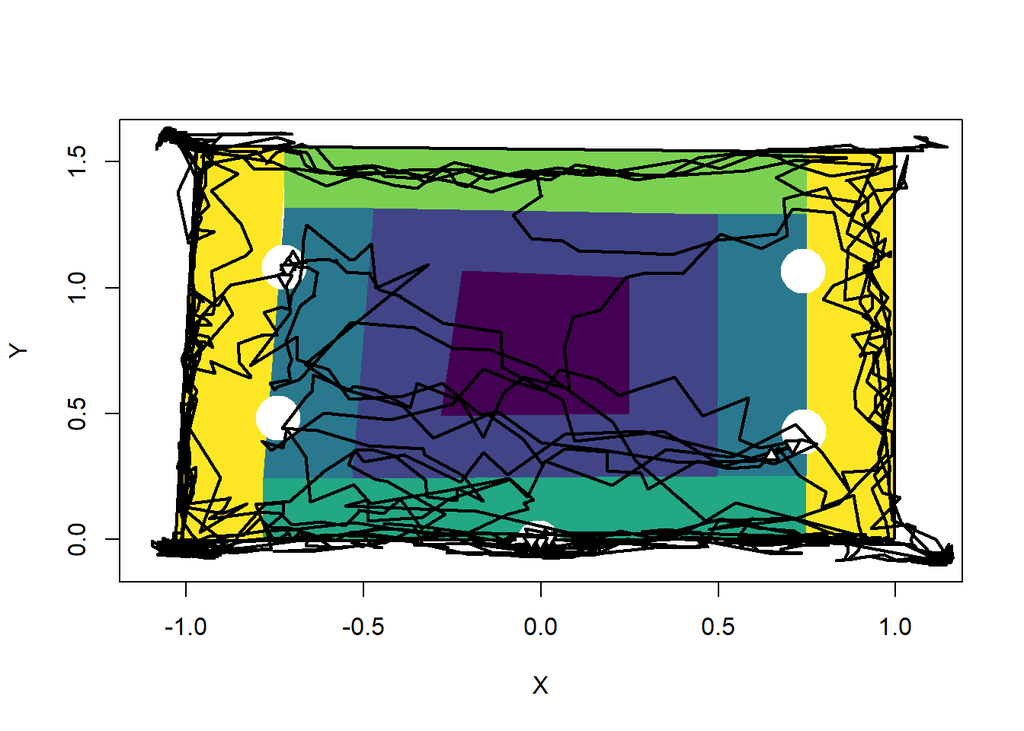

```r
data_visualization(ID, repeatability, time_limit)
```

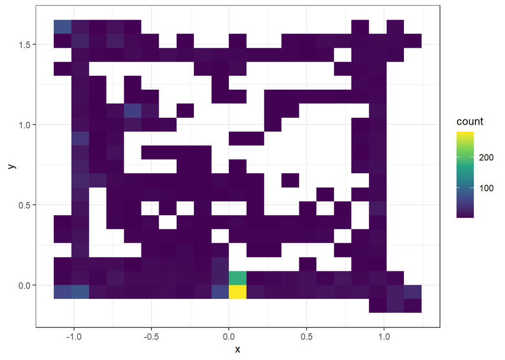

```r
density_function(ID, repeatability, time_limit)
```

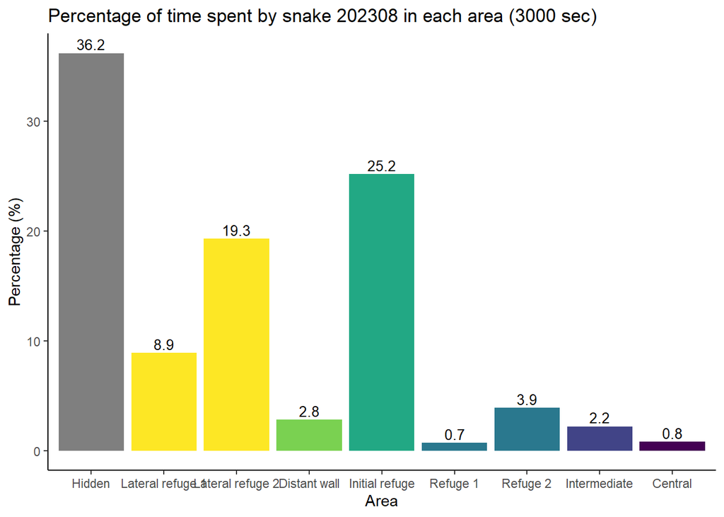

```r
graph_area(ID, repeatability, time_limit)
```

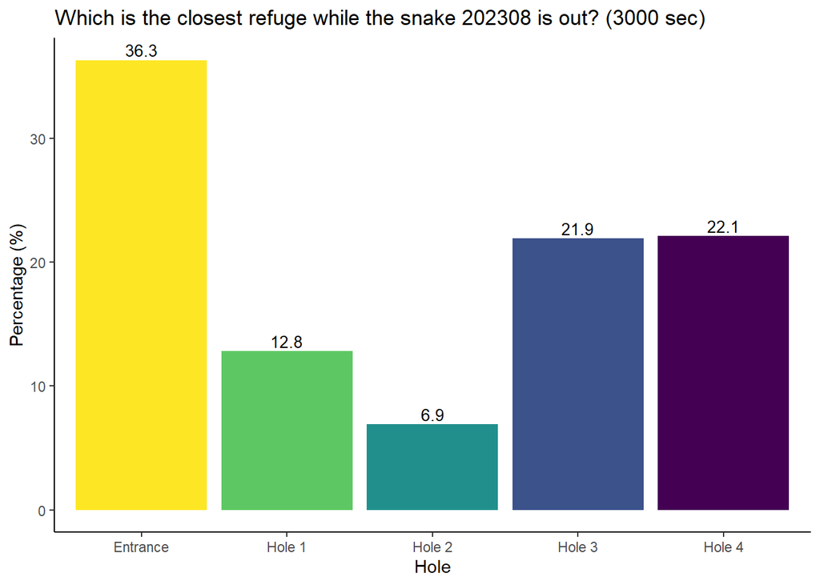

```r
graph_hole(ID, repeatability, time_limit)
```

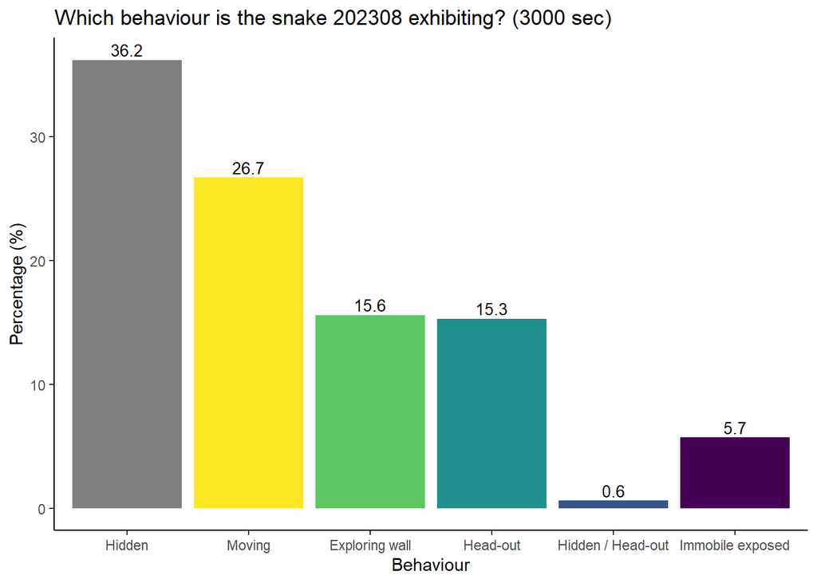

```r
graph_behaviour(ID, repeatability, time_limit)
```

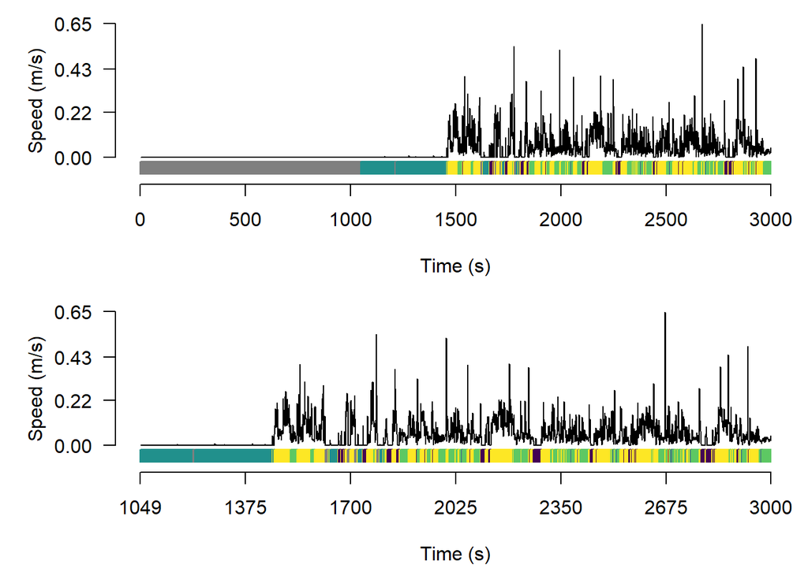

```r
speed_plot(ID, repeatability, time_limit)
```

# 5 Repeatability

In this part we study whether head-out, body-out and visual exploration behaviour are maintained in the same range of values for the same individual, demonstrating a certain repeatability in the experiments and a certain animal personality. In addition, it also allows us to see if there is any trend between different experimental trials depending on the area the snake comes from.

## 5.1 2023 snakes only

```r
# Read data from 2023 snakes
repeat_ID <- summary_tracking_complete$Snake_ID[duplicated(summary_tracking_complete$Snake_ID)]

# Select ind with more than one tracking
repeat_ind <- summary_tracking_complete[summary_tracking_complete$Snake_ID %in% repeat_ID, ]

# Assign 1 to first trials
repeat_ind$repeat_trial <- 1

for (i in 1:nrow(repeat_ind)){

  # And if duplicated, assign 2
  if(duplicated(repeat_ind$ID)[i] == T){

    repeat_ind$repeat_trial[i] <- 2

  } else {

  }

}

# Select variables of interest
repeat_ind <- repeat_ind[, c("Snake_ID", "Inv_situation", "Capture_day", "Time_head_out_sec_raw", "Time_body_out_sec_raw", "Repeatability", "Tracking", "Year_invasion", "Distance_Noahs", "SVL", "Real_Weight", "Condition", "Sex", "N_eggs", "repeat_trial")]

# Order snakes by ID (first the first trial and second the repeatiblity test)
repeat_ind <- repeat_ind[order(repeat_ind$Snake_ID), ]
```

### 5.1.1 Head-out

#### 5.1.1.1 Including gravid females

```r
# We extract the variable that we want to test repeatability
icc_data <- as.data.frame(repeat_ind[, c("Snake_ID", "Time_head_out_sec_raw", "repeat_trial", "Sex")])

# divide by sex
icc_data_F <- icc_data[icc_data$Sex == "F", ]

icc_data_M <- icc_data[icc_data$Sex == "M", ]

# Delete sex column
icc_data_F <- icc_data_F[, -c(4)]

icc_data_M <- icc_data_M[, -c(4)]

# Put it in wide format
icc_data_wide_F <- reshape(icc_data_F, idvar = "Snake_ID", timevar = "repeat_trial", direction = "wide")

icc_data_wide_M <- reshape(icc_data_M, idvar = "Snake_ID", timevar = "repeat_trial", direction = "wide")

# Delete ID column
icc_data_wide_F <- icc_data_wide_F[, -1]

icc_data_wide_M <- icc_data_wide_M[, -1]

# Change column names
colnames(icc_data_wide_F) <- c("First_trial", "Second_trial")

colnames(icc_data_wide_M) <- c("First_trial", "Second_trial")

# log transform varaibles
icc_data_wide_F <- log1p(icc_data_wide_F)

icc_data_wide_M <- log1p(icc_data_wide_M)

# Consistency (ICC)
# Females
irr::icc(icc_data_wide_F, model = "oneway", type = "consistency", unit = "single")
```

```
 Single Score Intraclass Correlation

   Model: oneway
   Type : consistency

   Subjects = 7
     Raters = 2
     ICC(1) = 0.688

 F-Test, H0: r0 = 0 ; H1: r0 > 0
     F(6,7) = 5.41 , p = 0.0217

 95%-Confidence Interval for ICC Population Values:
  0.028 < ICC < 0.937
```

```r
# Males
irr::icc(icc_data_wide_M, model = "oneway", type = "consistency", unit = "single")
```

```
 Single Score Intraclass Correlation

   Model: oneway
   Type : consistency

   Subjects = 11
     Raters = 2
     ICC(1) = 0.721

 F-Test, H0: r0 = 0 ; H1: r0 > 0
   F(10,11) = 6.16 , p = 0.00295

 95%-Confidence Interval for ICC Population Values:
  0.272 < ICC < 0.915
```

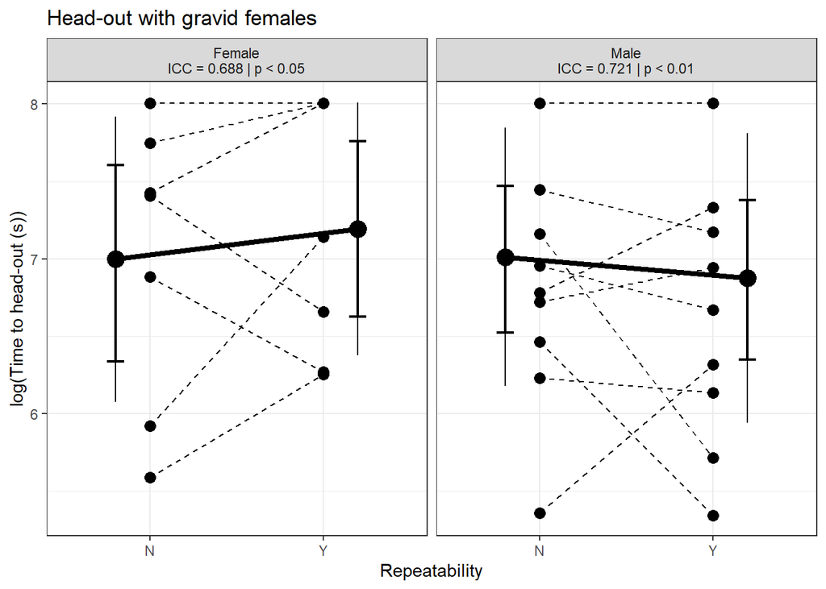

```r
# Plot
ggplot(data = repeat_ind, aes(x = Repeatability, y = log1p(Time_head_out_sec_raw))) +
  theme_bw() +
  facet_wrap(~ Sex, labeller = labeller(Sex =
                                          c("F" = "Female\nICC = 0.688 | p < 0.05",
                                            "M" = "Male\nICC = 0.721 | p < 0.01"))) +
  stat_summary(
    geom = "errorbar",
    fun.data = mean_cl_boot,
    width = 0.1,
    size = 0.8,
    col = "black",
    position = position_nudge(x = c(-0.2, 0.2))) +
  geom_point(size = 3) +
  stat_summary(fun.y = mean, position = position_nudge(x = c(-0.2, 0.2)), size = 1) +
  stat_summary(aes(group = 1), fun.y = mean, geom = "line", size = 1.5, linetype = "solid", position = position_nudge(x = c(-0.2, 0.2))) +
  stat_summary(fun.data = mean_sdl, fun.args = list(mult = 1),
               geom = "pointrange", color = "black", size = 0.2,
               position = position_nudge(x = c(-0.2, 0.2))) +
  geom_line(aes(group = Snake_ID), size = 0.5, linetype = "dashed") +
  ylab("log(Time to head-out (s))") +
  ggtitle("Head-out with gravid females") +
  theme(plot.caption = element_text(hjust = 0.5))
```

```r
# ANOVA differences in mean
# Females
anova_F <- aov(log(Time_head_out_sec_raw) ~ repeat_trial, data = icc_data_F)

summary(anova_F)
```

```
             Df Sum Sq Mean Sq F value Pr(>F)
repeat_trial  1  0.133  0.1334   0.175  0.683
Residuals    12  9.129  0.7607
```

```r
# Males
anova_M <- aov(log(Time_head_out_sec_raw) ~ repeat_trial, data = icc_data_M)

summary(anova_M)
```

```
             Df Sum Sq Mean Sq F value Pr(>F)
repeat_trial  1  0.102  0.1016   0.129  0.723
Residuals    20 15.758  0.7879
```

#### 5.1.1.2 Excluding gravid females

```r
# Data frame without gravid females
repeat_ind_no_gravid <- repeat_ind[repeat_ind$N_eggs == 0, ]

# We extract the variable that we want to test repeatability
icc_data <- as.data.frame(repeat_ind[, c("Snake_ID", "Time_head_out_sec_raw", "repeat_trial", "Sex", "N_eggs")])

# Do not include gravid females
icc_data <- icc_data[icc_data$N_eggs == 0, ]

# divide by sex
icc_data_F <- icc_data[icc_data$Sex == "F", ]

icc_data_M <- icc_data[icc_data$Sex == "M", ]

# Delete sex and n_eggs columns
icc_data_F <- icc_data_F[, -c(4, 5)]

icc_data_M <- icc_data_M[, -c(4, 5)]

# Put it in wide format
icc_data_wide_F <- reshape(icc_data_F, idvar = "Snake_ID", timevar = "repeat_trial", direction = "wide")

icc_data_wide_M <- reshape(icc_data_M, idvar = "Snake_ID", timevar = "repeat_trial", direction = "wide")

# Delete ID column
icc_data_wide_F <- icc_data_wide_F[, -1]

icc_data_wide_M <- icc_data_wide_M[, -1]

# Change column names
colnames(icc_data_wide_F) <- c("First_trial", "Second_trial")

colnames(icc_data_wide_M) <- c("First_trial", "Second_trial")

# log transform varaibles
icc_data_wide_F <- log1p(icc_data_wide_F)

icc_data_wide_M <- log1p(icc_data_wide_M)

# Consistency (ICC)
# Females
irr::icc(icc_data_wide_F, model = "oneway", type = "consistency", unit = "single")
```

```
 Single Score Intraclass Correlation

   Model: oneway
   Type : consistency

   Subjects = 5
     Raters = 2
     ICC(1) = 0.785

 F-Test, H0: r0 = 0 ; H1: r0 > 0
     F(4,5) = 8.32 , p = 0.0195

 95%-Confidence Interval for ICC Population Values:
  0.06 < ICC < 0.975
```

```r
# Males
irr::icc(icc_data_wide_M, model = "oneway", type = "consistency", unit = "single")
```

```
 Single Score Intraclass Correlation

   Model: oneway
   Type : consistency

   Subjects = 11
     Raters = 2
     ICC(1) = 0.721

 F-Test, H0: r0 = 0 ; H1: r0 > 0
   F(10,11) = 6.16 , p = 0.00295

 95%-Confidence Interval for ICC Population Values:
  0.272 < ICC < 0.915
```

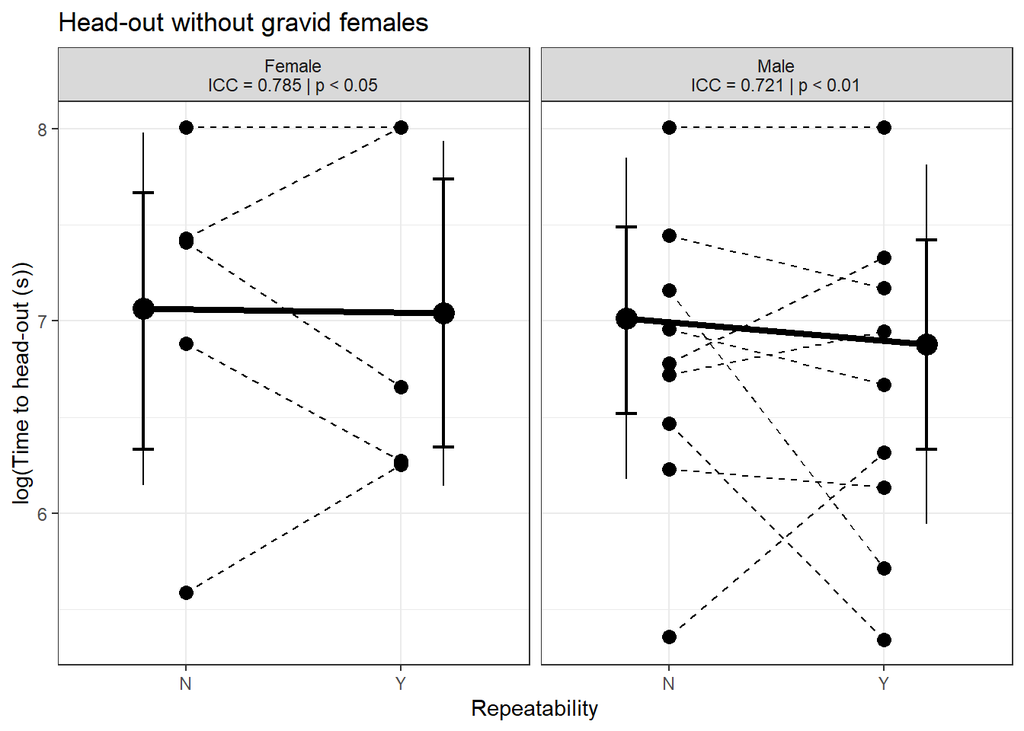

```r
# Plot
ggplot(data = repeat_ind_no_gravid, aes(x = Repeatability, y = log1p(Time_head_out_sec_raw))) +
  theme_bw() +
  facet_wrap(~ Sex, labeller = labeller(Sex =
                                          c("F" = "Female\nICC = 0.785 | p < 0.05",
                                            "M" = "Male\nICC = 0.721 | p < 0.01"))) +
  stat_summary(
    geom = "errorbar",
    fun.data = mean_cl_boot,
    width = 0.1,
    size = 0.8,
    col = "black",
    position = position_nudge(x = c(-0.2, 0.2))) +
  geom_point(size = 3) +
  stat_summary(fun.y = mean, position = position_nudge(x = c(-0.2, 0.2)), size = 1) +
  stat_summary(aes(group = 1), fun.y = mean, geom = "line", size = 1.5, linetype = "solid", position = position_nudge(x = c(-0.2, 0.2))) +
  stat_summary(fun.data = mean_sdl, fun.args = list(mult = 1),
               geom = "pointrange", color = "black", size = 0.2,
               position = position_nudge(x = c(-0.2, 0.2))) +
  geom_line(aes(group = Snake_ID), size = 0.5, linetype = "dashed") +
  ylab("log(Time to head-out (s))") +
  ggtitle("Head-out without gravid females") +
  theme(plot.caption = element_text(hjust = 0.5))
```

```r
# ANOVA differences in mean
# Females
anova_F <- aov(log(Time_head_out_sec_raw) ~ repeat_trial, data = icc_data_F)

summary(anova_F)
```

```
             Df Sum Sq Mean Sq F value Pr(>F)
repeat_trial  1  0.001  0.0014   0.002  0.969
Residuals     8  6.593  0.8241
```

```r
# Males
anova_M <- aov(log(Time_head_out_sec_raw) ~ repeat_trial, data = icc_data_M)

summary(anova_M)
```

```
             Df Sum Sq Mean Sq F value Pr(>F)
repeat_trial  1  0.102  0.1016   0.129  0.723
Residuals    20 15.758  0.7879
```